# SLF_Project_TemplateNotebook-Final-A Graham

## Context

Buying and selling used smartphones used to be something that happened on a handful of online marketplace sites. But the used and refurbished phone market has grown considerably over the past decade, and a new IDC (International Data Corporation) forecast predicts that the used phone market would be worth $52.7bn by 2023 with a compound annual growth rate (CAGR) of 13.6% from 2018 to 2023. This growth can be attributed to an uptick in demand for used smartphones that offer considerable savings compared with new models.

Refurbished and used devices continue to provide cost-effective alternatives to both consumers and businesses that are looking to save money when purchasing a smartphone. There are plenty of other benefits associated with the used smartphone market. Used and refurbished devices can be sold with warranties and can also be insured with proof of purchase. Third-party vendors/platforms, such as Verizon, Amazon, etc., provide attractive offers to customers for refurbished smartphones. Maximizing the longevity of mobile phones through second-hand trade also reduces their environmental impact and helps in recycling and reducing waste. The impact of the COVID-19 outbreak may further boost the cheaper refurbished smartphone segment, as consumers cut back on discretionary spending and buy phones only for immediate needs.

## Objectives

The rising potential of this comparatively under-the-radar market fuels the need for an ML-based solution to develop a dynamic pricing strategy for used and refurbished smartphones. ReCell, a startup aiming to tap the potential in this market, has hired as a data scientist. The objectives are :

- To analyze the data provided and build a linear regression model to predict the price of a used phone and identify factors that significantly influence it.
- Answer key questions given below

## Key Questions

**Questions**:

1. What does the distribution of used phone prices look like?
2. What percentage of the used phone market is dominated by Android devices?
3. The amount of RAM is important for the smooth functioning of a phone. How does the amount of RAM vary with the brand?
4. A large battery often increases a phone's weight, making it feel uncomfortable in the hands. How does the weight vary for phones offering large batteries (more than 4500 mAh)?
5. Bigger screens are desirable for entertainment purposes as they offer a better viewing experience. How many phones are available across different brands with a screen size larger than 6 inches?
6. Budget phones nowadays offer great selfie cameras, allowing us to capture our favorite moments with loved ones. What is the distribution of budget phones offering greater than 8MP selfie cameras across brands?
7. Which attributes are highly correlated with the used phone price?

## Data Description

The data contains the different attributes of used/refurbished phones. The detailed data dictionary is given below.

### Data Dictionary

- brand_name: Name of manufacturing brand
- os: OS on which the phone runs
- screen_size: Size of the screen in cm
- 4g: Whether 4G is available or not
- 5g: Whether 5G is available or not
- main_camera_mp: Resolution of the rear camera in megapixels
- selfie_camera_mp: Resolution of the front camera in megapixels
- int_memory: Amount of internal memory (ROM) in GB
- ram: Amount of RAM in GB
- battery: Energy capacity of the phone battery in mAh
- weight: Weight of the phone in grams
- release_year: Year when the phone model was released
- days_used: Number of days the used/refurbished phone has been used
- new_price: Price of a new phone of the same model in euros
- used_price: Price of the used/refurbished phone in euros

## Importing necessary libraries and data

```python
# this will help in making the Python code more structured automatically (good coding practice)
%reload_ext nb_black

# Libraries to help with reading and manipulating data
import numpy as np
import pandas as pd

# Libraries to help with data visualization
import matplotlib.pyplot as plt
import seaborn as sns

sns.set()

# to split the data into train and test
from sklearn.model_selection import train_test_split

# to build linear regression_model
from sklearn.linear_model import LinearRegression

# to check model performance
from sklearn.metrics import mean_absolute_error, mean_squared_error, r2_score

# to build linear regression_model using statsmodels
import statsmodels.api as sm

pd.set_option("display.max_columns", None)
pd.set_option(
    "display.float_format", lambda x: "%.2f" % x
)  # To supress numerical display in scientific notations
```

```python
# loading the dataset

data = pd.read_csv("used_phone_data.csv")
```

```python
# Let's create a copy of the data to avoid any changes to original data.
df = data.copy()
```

```python
df.columns
```

```
Index(['brand_name', 'os', 'screen_size', '4g', '5g', 'main_camera_mp',
       'selfie_camera_mp', 'int_memory', 'ram', 'battery', 'weight',
       'release_year', 'days_used', 'new_price', 'used_price'],
      dtype='object')
```

## Data Overview

- Observations
- Sanity checks

```python
# code to examine the 1st 5 rows of the data
df.head()
```

|  | brand_name | os | screen_size | 4g | 5g | main_camera_mp | selfie_camera_mp | int_memory | ram | battery | weight | release_year | days_used | new_price | used_price |
| --- | --- | --- | --- | --- | --- | --- | --- | --- | --- | --- | --- | --- | --- | --- | --- |
| 0 | Honor | Android | 23.97 | yes | no | 13.00 | 5.00 | 64.00 | 3.00 | 3020.00 | 146.00 | 2020 | 127 | 111.62 | 86.96 |
| 1 | Honor | Android | 28.10 | yes | yes | 13.00 | 16.00 | 128.00 | 8.00 | 4300.00 | 213.00 | 2020 | 325 | 249.39 | 161.49 |
| 2 | Honor | Android | 24.29 | yes | yes | 13.00 | 8.00 | 128.00 | 8.00 | 4200.00 | 213.00 | 2020 | 162 | 359.47 | 268.55 |
| 3 | Honor | Android | 26.04 | yes | yes | 13.00 | 8.00 | 64.00 | 6.00 | 7250.00 | 480.00 | 2020 | 345 | 278.93 | 180.23 |
| 4 | Honor | Android | 15.72 | yes | no | 13.00 | 8.00 | 64.00 | 3.00 | 5000.00 | 185.00 | 2020 | 293 | 140.87 | 103.80 |

```python
# Checking number of rows and columns
df.shape
```

```
(3571, 15)
```

#### The dataset has 3571 rows and 15 columns

```python
# checking column datatypes and number of  non-null values
df.info()
```

```
<class 'pandas.core.frame.DataFrame'>
RangeIndex: 3571 entries, 0 to 3570
Data columns (total 15 columns):
 #   Column            Non-Null Count  Dtype
---  ------            --------------  -----
 0   brand_name        3571 non-null   object
 1   os                3571 non-null   object
 2   screen_size       3571 non-null   float64
 3   4g                3571 non-null   object
 4   5g                3571 non-null   object
 5   main_camera_mp    3391 non-null   float64
 6   selfie_camera_mp  3569 non-null   float64
 7   int_memory        3561 non-null   float64
 8   ram               3561 non-null   float64
 9   battery           3565 non-null   float64
 10  weight            3564 non-null   float64
 11  release_year      3571 non-null   int64
 12  days_used         3571 non-null   int64
 13  new_price         3571 non-null   float64
 14  used_price        3571 non-null   float64
dtypes: float64(9), int64(2), object(4)
memory usage: 418.6+ KB
```

#### Observations

- Four columns are coded as objects, while 11 columns are coded as numeric.
- Data such as `ram`, `internal memory` , `main` and `selfie camera` are classified as numeric, but should be categorical
- `Release year` should also be treated as categorical since a Phone Model falls into a discrete bracket i.e either 2015 or 2016 Model etc

```python
# code to get the description of all numerical variables.
df.describe(include="all").T
```

|  | count | unique | top | freq | mean | std | min | 25% | 50% | 75% | max |
| --- | --- | --- | --- | --- | --- | --- | --- | --- | --- | --- | --- |
| brand_name | 3571 | 34 | Others | 509 | NaN | NaN | NaN | NaN | NaN | NaN | NaN |
| os | 3571 | 4 | Android | 3246 | NaN | NaN | NaN | NaN | NaN | NaN | NaN |
| screen_size | 3571.00 | NaN | NaN | NaN | 14.80 | 5.15 | 2.70 | 12.70 | 13.49 | 16.51 | 46.36 |
| 4g | 3571 | 2 | yes | 2359 | NaN | NaN | NaN | NaN | NaN | NaN | NaN |
| 5g | 3571 | 2 | no | 3419 | NaN | NaN | NaN | NaN | NaN | NaN | NaN |
| main_camera_mp | 3391.00 | NaN | NaN | NaN | 9.40 | 4.82 | 0.08 | 5.00 | 8.00 | 13.00 | 48.00 |
| selfie_camera_mp | 3569.00 | NaN | NaN | NaN | 6.55 | 6.88 | 0.30 | 2.00 | 5.00 | 8.00 | 32.00 |
| int_memory | 3561.00 | NaN | NaN | NaN | 54.53 | 84.70 | 0.01 | 16.00 | 32.00 | 64.00 | 1024.00 |
| ram | 3561.00 | NaN | NaN | NaN | 4.06 | 1.39 | 0.03 | 4.00 | 4.00 | 4.00 | 16.00 |
| battery | 3565.00 | NaN | NaN | NaN | 3067.23 | 1364.21 | 80.00 | 2100.00 | 3000.00 | 4000.00 | 12000.00 |
| weight | 3564.00 | NaN | NaN | NaN | 179.42 | 90.28 | 23.00 | 140.00 | 159.00 | 184.00 | 950.00 |
| release_year | 3571.00 | NaN | NaN | NaN | 2015.96 | 2.29 | 2013.00 | 2014.00 | 2016.00 | 2018.00 | 2020.00 |
| days_used | 3571.00 | NaN | NaN | NaN | 675.39 | 248.64 | 91.00 | 536.00 | 690.00 | 872.00 | 1094.00 |
| new_price | 3571.00 | NaN | NaN | NaN | 237.39 | 197.55 | 9.13 | 120.13 | 189.80 | 291.94 | 2560.20 |
| used_price | 3571.00 | NaN | NaN | NaN | 109.88 | 121.50 | 2.51 | 45.20 | 75.53 | 126.00 | 1916.54 |

**Observations**

In the used phone Market :

- The most popular operating system is Android
- Most of the phones have only 4g capability
- The mean used price is ~110 euros
- The mean days_used is 675 days
- The average ram size is 4 GB

### Converting the data types

```python
# Converting some of the numeric data types to categorical since they are discrete variables
df["ram"] = df["ram"].astype("category")
df["int_memory"] = df["int_memory"].astype("category")
df["release_year"] = df["release_year"].astype("category")
df["main_camera_mp"] = df["main_camera_mp"].astype("category")
```

#### selfie camera is converted later on in the analysis to categorical -Output 40

## Exploratory Data Analysis (EDA)

- EDA is an important part of any project involving data.
- It is important to investigate and understand the data better before building a model with it.
- A few questions have been mentioned below to help approach the analysis in the right manner and generate insights from the data.
- A thorough analysis of the data, in addition to the questions mentioned below, should be done.

**Questions**:

1. What does the distribution of used phone prices look like?
2. What percentage of the used phone market is dominated by Android devices?
3. The amount of RAM is important for the smooth functioning of a phone. How does the amount of RAM vary with the brand?
4. A large battery often increases a phone's weight, making it feel uncomfortable in the hands. How does the weight vary for phones offering large batteries (more than 4500 mAh)?
5. Bigger screens are desirable for entertainment purposes as they offer a better viewing experience. How many phones are available across different brands with a screen size larger than 6 inches?
6. Budget phones nowadays offer great selfie cameras, allowing us to capture our favorite moments with loved ones. What is the distribution of budget phones offering greater than 8MP selfie cameras across brands?
7. Which attributes are highly correlated with the used phone price?

### Univariate Analysis

```python
# function to plot a boxplot and a histogram along the same scale.


def histogram_boxplot(data, feature, figsize=(12, 7), kde=False, bins=None):
    """
    Boxplot and histogram combined

    data: dataframe
    feature: dataframe column
    figsize: size of figure (default (12,7))
    kde: whether to the show density curve (default False)
    bins: number of bins for histogram (default None)
    """
    f2, (ax_box2, ax_hist2) = plt.subplots(
        nrows=2,  # Number of rows of the subplot grid= 2
        sharex=True,  # x-axis will be shared among all subplots
        gridspec_kw={"height_ratios": (0.25, 0.75)},
        figsize=figsize,
    )  # creating the 2 subplots
    sns.boxplot(
        data=data, x=feature, ax=ax_box2, showmeans=True, color="violet"
    )  # boxplot will be created and a star will indicate the mean value of the column
    sns.histplot(
        data=data, x=feature, kde=kde, ax=ax_hist2, bins=bins, palette="winter"
    ) if bins else sns.histplot(
        data=data, x=feature, kde=kde, ax=ax_hist2
    )  # For histogram
    ax_hist2.axvline(
        data[feature].mean(), color="green", linestyle="--"
    )  # Add mean to the histogram
    ax_hist2.axvline(
        data[feature].median(), color="black", linestyle="-"
    )  # Add median to the histogram
```

### Let's explore screen size

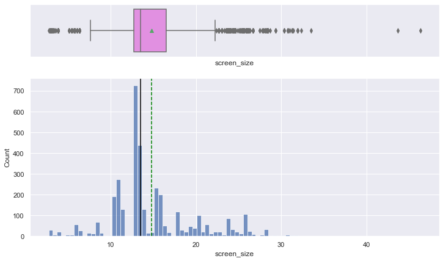

```python
# function to create labelled box plot
histogram_boxplot(df, "screen_size")
```

**Observation**

### Let's explore weight

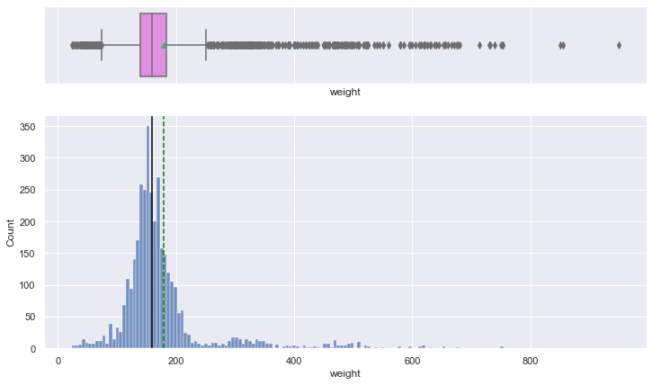

```python
# function to create labelled box plot
histogram_boxplot(df, "weight")
```

**Observation**

- Weight appears to be a normal distribution
- The data is skewed to the right
- There are outliers above the upper and lower whiskers
- Weight has missing values that will be filled in with the Median value due to the outliers

### Let's explore days_used

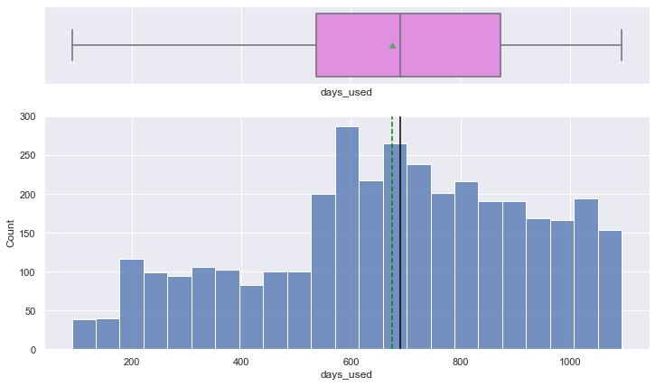

```python
# function to create labelled box plot
histogram_boxplot(df, "days_used")
```

**Observation**

- Days used appears to be left skewed
- There are no outliers in the data
- The mean used days of a cellphone in the data set is 675 days or 1.85 yrs

### Let's explore new_price

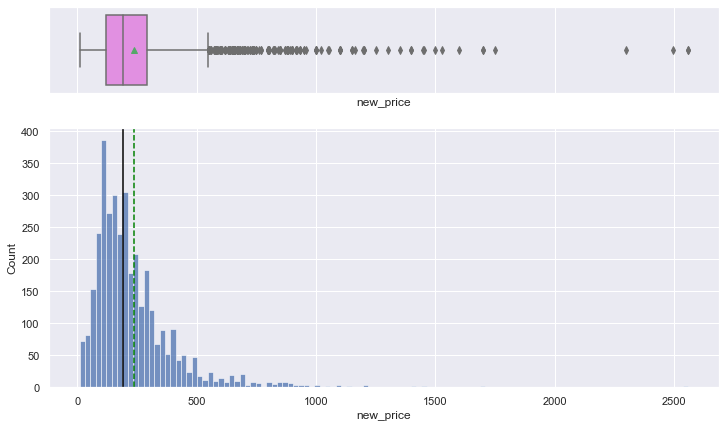

```python
# function to create labelled box plot
histogram_boxplot(df, "new_price")
```

**Observation**

### Let's explore used_price

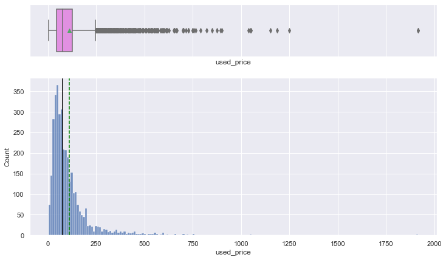

```python
# function to create labelled box plot
histogram_boxplot(df, "used_price")
```

**Observation**

- Used price appears to be right skewed.
- There are a lot of outliers above the upper whisker.
- Most of the prices are less than 250 euros

### Let's analyse `budget` phones with greater than 8mp selfie cameras, while we are on price.

### Let's define a budget phone as having a price less `$100` euros or `less`

```python
## Let's create a dataframe containing phones of value $100 euros or less

df_budget = df[df["used_price"] <= 100]

## Let's look at budget phones with selfie cameras greater than 8mp
df_selfie_8 = df_budget[df_budget["selfie_camera_mp"] > 8]
df_selfie_8
```

|  | brand_name | os | screen_size | 4g | 5g | main_camera_mp | selfie_camera_mp | int_memory | ram | battery | weight | release_year | days_used | new_price | used_price |
| --- | --- | --- | --- | --- | --- | --- | --- | --- | --- | --- | --- | --- | --- | --- | --- |
| 13 | Honor | Others | 8.73 | no | no | 13.00 | 16.00 | 4.00 | 4.00 | 455.00 | 41.00 | 2019 | 432 | 179.62 | 89.77 |
| 18 | Honor | Android | 24.61 | yes | no | 13.00 | 16.00 | 64.00 | 4.00 | 4000.00 | 206.00 | 2019 | 421 | 180.04 | 90.02 |
| 63 | Infinix | Android | 16.19 | yes | no | NaN | 16.00 | 32.00 | 3.00 | 4000.00 | 178.00 | 2019 | 316 | 99.70 | 64.51 |
| 64 | Infinix | Android | 15.56 | yes | no | NaN | 16.00 | 32.00 | 2.00 | 4000.00 | 165.00 | 2019 | 468 | 130.49 | 65.29 |
| 75 | Lenovo | Android | 15.72 | yes | no | 8.00 | 16.00 | 64.00 | 4.00 | 4050.00 | 164.00 | 2019 | 482 | 157.98 | 78.79 |
| ... | ... | ... | ... | ... | ... | ... | ... | ... | ... | ... | ... | ... | ... | ... | ... |
| 3501 | Nokia | Android | 15.72 | yes | no | 5.00 | 20.00 | 64.00 | 4.00 | 3500.00 | 180.00 | 2019 | 459 | 168.56 | 84.20 |
| 3514 | Oppo | Android | 16.03 | yes | no | 8.00 | 16.00 | 128.00 | 4.00 | 5000.00 | 195.00 | 2019 | 481 | 152.99 | 76.54 |
| 3527 | Realme | Android | 15.88 | yes | no | NaN | 16.00 | 64.00 | 4.00 | 4000.00 | 183.00 | 2019 | 503 | 174.16 | 86.88 |
| 3528 | Realme | Android | 15.72 | yes | no | NaN | 16.00 | 64.00 | 4.00 | 4035.00 | 184.00 | 2019 | 433 | 159.88 | 80.00 |
| 3550 | Samsung | Android | 15.88 | yes | no | 12.00 | 16.00 | 64.00 | 4.00 | 6000.00 | 188.00 | 2019 | 455 | 165.66 | 82.79 |

106 rows × 15 columns

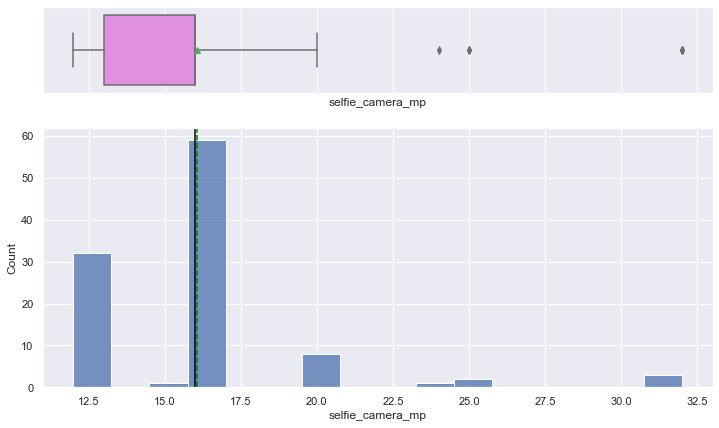

```python
# function to create labelled box plot of budget phones (100 euros or less), that have selfie camera mp > 8 mp
histogram_boxplot(df_selfie_8, "selfie_camera_mp")
```

**Observation**

- There are `106 budget phones` that have cameras with selfie camera resolution greater than 8 mp
- The distribution is right skewed with a mean of around 16mp

### Let's analyze battery

```python
# This code looks at the battery counts in the various mAh categories
df["battery"].value_counts()
```

```
4000.00    341
3000.00    318
2000.00    245
2500.00    137
2100.00    121
          ...
1170.00      1
4235.00      1
3730.00      1
2256.00      1
7400.00      1
Name: battery, Length: 354, dtype: int64
```

There are 354 categories of batteries ranging from 80 mAh to 12000 mAh. Let's look at batteries over 4500mAh

```python
## Let's look at batteries over 4500mAh and the distribution of their weights
## Thiis code filters to show batteries above 4500 mAh
df_bat = df[df["battery"] > 4500]
df_bat
```

|  | brand_name | os | screen_size | 4g | 5g | main_camera_mp | selfie_camera_mp | int_memory | ram | battery | weight | release_year | days_used | new_price | used_price |
| --- | --- | --- | --- | --- | --- | --- | --- | --- | --- | --- | --- | --- | --- | --- | --- |
| 3 | Honor | Android | 26.04 | yes | yes | 13.00 | 8.00 | 64.00 | 6.00 | 7250.00 | 480.00 | 2020 | 345 | 278.93 | 180.23 |
| 4 | Honor | Android | 15.72 | yes | no | 13.00 | 8.00 | 64.00 | 3.00 | 5000.00 | 185.00 | 2020 | 293 | 140.87 | 103.80 |
| 11 | Honor | Android | 15.72 | yes | no | 13.00 | 8.00 | 64.00 | 4.00 | 5000.00 | 185.00 | 2020 | 344 | 117.94 | 74.60 |
| 20 | Honor | Android | 25.56 | yes | no | 5.00 | 2.00 | 32.00 | 3.00 | 5100.00 | 173.00 | 2019 | 266 | 248.90 | 167.63 |
| 21 | Honor | Android | 20.32 | yes | no | 8.00 | 8.00 | 32.00 | 3.00 | 5100.00 | 173.00 | 2019 | 321 | 201.14 | 131.89 |
| ... | ... | ... | ... | ... | ... | ... | ... | ... | ... | ... | ... | ... | ... | ... | ... |
| 3536 | Samsung | Android | 16.67 | yes | yes | 8.00 | 13.00 | 128.00 | 12.00 | 5000.00 | 222.00 | 2020 | 197 | 890.80 | 667.92 |
| 3537 | Samsung | Android | 16.67 | yes | no | 8.00 | 13.00 | 128.00 | 12.00 | 5000.00 | 220.00 | 2020 | 176 | 1054.45 | 789.54 |
| 3550 | Samsung | Android | 15.88 | yes | no | 12.00 | 16.00 | 64.00 | 4.00 | 6000.00 | 188.00 | 2019 | 455 | 165.66 | 82.79 |
| 3565 | Asus | Android | 24.61 | yes | no | NaN | 24.00 | 128.00 | 8.00 | 6000.00 | 240.00 | 2019 | 325 | 1163.65 | 756.99 |
| 3566 | Asus | Android | 15.88 | yes | no | NaN | 8.00 | 64.00 | 6.00 | 5000.00 | 190.00 | 2019 | 232 | 654.50 | 490.96 |

346 rows × 15 columns

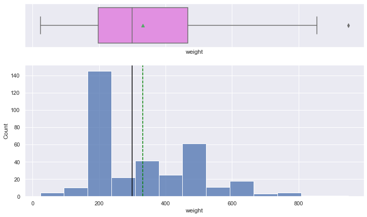

```python
# function to create labelled box plot for distribution of phone weights that have batteries with capacity > 4500mAh
histogram_boxplot(df_bat, "weight")
```

```python
# code to find the mean weight of phones over 4500mAh
round(df_bat["weight"].mean(), 2)
```

```
330.72
```

**Observation**

For phones with battery capacities > 4500mAh these are the observations below.

- There are over 140 phones with weights in the 200 g class.
- The mean weight of phones over 4500mAh is 330 grams

### Let's explore the categorical features

```python
# function to create labeled barplots


def labeled_barplot(data, feature, perc=False, n=None):
    """
    Barplot with percentage at the top

    data: dataframe
    feature: dataframe column
    perc: whether to display percentages instead of count (default is False)
    n: displays the top n category levels (default is None, i.e., display all levels)
    """

    total = len(data[feature])  # length of the column
    count = data[feature].nunique()
    if n is None:
        plt.figure(figsize=(count + 1, 7))
    else:
        plt.figure(figsize=(n + 1, 7))

    plt.xticks(rotation=90, fontsize=15)
    ax = sns.countplot(
        data=data,
        x=feature,
        palette="Paired",
        order=data[feature].value_counts().index[:n].sort_values(),
    )

    for p in ax.patches:
        if perc == True:
            label = "{:.1f}%".format(
                100 * p.get_height() / total
            )  # percentage of each class of the category
        else:
            label = p.get_height()  # count of each level of the category

        x = p.get_x() + p.get_width() / 2  # width of the plot
        y = p.get_height()  # height of the plot

        ax.annotate(
            label,
            (x, y),
            ha="center",
            va="center",
            size=12,
            xytext=(0, 5),
            textcoords="offset points",
        )  # annotate the percentage

    plt.show()  # show the plot
```

### Let's explore brand_name

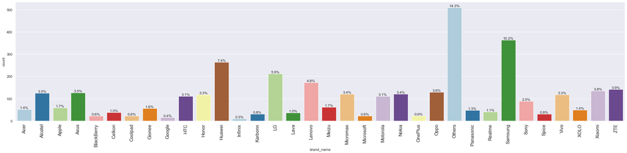

```python
# function to create labelled bar plot
labeled_barplot(df, "brand_name", perc=True)
```

```python
# Code to see the number of unique names in the series "brand_name"
len(df["brand_name"].unique())
```

```
34
```

```python
# Code to see the number of phones in each of the brand names
df["brand_name"].value_counts()
```

```
Others        509
Samsung       364
Huawei        264
LG            212
Lenovo        172
ZTE           141
Xiaomi        134
Oppo          129
Asus          126
Alcatel       125
Nokia         121
Micromax      120
Honor         118
Vivo          117
Motorola      110
HTC           110
Sony           88
Meizu          62
Apple          59
Gionee         56
Acer           51
XOLO           49
Panasonic      47
Realme         41
Celkon         37
Lava           36
Karbonn        30
Spice          30
BlackBerry     22
OnePlus        22
Microsoft      22
Coolpad        22
Google         15
Infinix        10
Name: brand_name, dtype: int64
```

**Observation**

- There are 34 brand categories with Others, Samsung and Huawei being the top 3 brands

### Let's look at phones with screen sizes more than 6 inches

```python
# This code filters screens sizes more than 6 inches
df_screen = df[df["screen_size"] > 6]

# This code sorts the dataframe to show the largest screen size first
df_screen.sort_values(by=["screen_size"], ascending=False, inplace=False)
```

|  | brand_name | os | screen_size | 4g | 5g | main_camera_mp | selfie_camera_mp | int_memory | ram | battery | weight | release_year | days_used | new_price | used_price |
| --- | --- | --- | --- | --- | --- | --- | --- | --- | --- | --- | --- | --- | --- | --- | --- |
| 2562 | Samsung | Android | 46.36 | yes | no | 2.10 | 5.00 | 32.00 | 4.00 | 5700.00 | 65.00 | 2015 | 627 | 639.87 | 255.73 |
| 387 | Samsung | Android | 43.66 | yes | no | 12.00 | 5.00 | 64.00 | 3.00 | 12000.00 | 23.00 | 2019 | 266 | 659.47 | 460.58 |
| 1646 | Lenovo | Android | 33.50 | yes | no | 8.00 | 1.60 | 32.00 | 4.00 | 9600.00 | 950.00 | 2014 | 1085 | 409.19 | 122.83 |
| 204 | Xiaomi | Android | 32.39 | yes | yes | 12.00 | 20.00 | 512.00 | 12.00 | 4050.00 | 241.00 | 2019 | 478 | 2498.24 | 1248.99 |
| 697 | Apple | iOS | 31.91 | yes | no | 8.00 | 1.20 | 32.00 | 4.00 | 3937.00 | 713.00 | 2015 | 572 | 849.52 | 424.88 |
| ... | ... | ... | ... | ... | ... | ... | ... | ... | ... | ... | ... | ... | ... | ... | ... |
| 1000 | Celkon | Others | 6.03 | no | no | 0.30 | 0.30 | 256.00 | 0.25 | 1400.00 | 140.00 | 2013 | 687 | 21.51 | 8.59 |
| 999 | Celkon | Others | 6.03 | no | no | 1.30 | 0.30 | 256.00 | 0.25 | 1400.00 | 140.00 | 2013 | 796 | 20.56 | 8.21 |
| 520 | Alcatel | Others | 6.03 | no | no | 5.00 | 2.00 | 16.00 | 4.00 | 210.00 | 142.95 | 2015 | 554 | 110.97 | 55.63 |
| 1999 | Micromax | Others | 6.03 | no | no | 0.30 | 0.30 | 16.00 | 4.00 | 2000.00 | 118.00 | 2013 | 596 | 19.21 | 9.74 |
| 1014 | Celkon | Others | 6.03 | no | no | 1.30 | 0.30 | 256.00 | 0.25 | 3000.00 | 140.00 | 2013 | 787 | 29.51 | 11.96 |

3450 rows × 15 columns

```python
# let's create a datframe consisting of the brand_name and screen_size columns
df_screen2 = df_screen[["brand_name", "screen_size"]].copy()

# This code groups the dataframe by the mean screen size first
df_screen3 = (
    df_screen2.groupby("brand_name")[["screen_size"]]
    .mean()
    .sort_values(by=["screen_size"], ascending=False, inplace=False)
)

# This code resets the index so thatthe variable brand_name is now an available column to use in further data manipulations such as plots
df_screen4 = df_screen3.reset_index()
df_screen4
```

|  | brand_name | screen_size |
| --- | --- | --- |
| 0 | OnePlus | 20.81 |
| 1 | Honor | 19.05 |
| 2 | Vivo | 19.03 |
| 3 | Xiaomi | 19.00 |
| 4 | Infinix | 18.48 |
| 5 | Apple | 17.76 |
| 6 | Realme | 17.66 |
| 7 | Huawei | 17.50 |
| 8 | Lenovo | 16.11 |
| 9 | Oppo | 15.58 |
| 10 | Asus | 15.51 |
| 11 | Acer | 15.25 |
| 12 | Meizu | 15.22 |
| 13 | Samsung | 15.18 |
| 14 | Google | 15.06 |
| 15 | Nokia | 14.41 |
| 16 | Others | 14.33 |
| 17 | Sony | 14.18 |
| 18 | Motorola | 14.15 |
| 19 | LG | 14.09 |
| 20 | ZTE | 14.06 |
| 21 | Coolpad | 14.04 |
| 22 | Gionee | 13.62 |
| 23 | Alcatel | 13.60 |
| 24 | Microsoft | 13.01 |
| 25 | Panasonic | 13.00 |
| 26 | HTC | 12.97 |
| 27 | XOLO | 12.48 |
| 28 | Lava | 12.47 |
| 29 | BlackBerry | 12.41 |
| 30 | Micromax | 12.40 |
| 31 | Spice | 11.75 |
| 32 | Karbonn | 11.68 |
| 33 | Celkon | 10.48 |

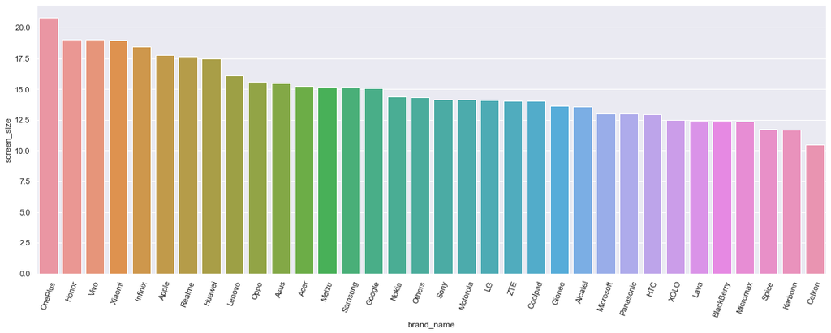

```python
plt.figure(figsize=(20, 7))
sns.barplot(x=df_screen4["brand_name"], y=df_screen4["screen_size"])
plt.xticks(rotation=70)
plt.show()
```

```python
# code to verify the different brand names in the data frame of cellphones having screen sizes > 6 inches
df_screen["brand_name"].unique()
```

```
array(['Honor', 'Others', 'HTC', 'Huawei', 'Infinix', 'Lava', 'Lenovo',
       'LG', 'Meizu', 'Micromax', 'Motorola', 'Nokia', 'OnePlus', 'Oppo',
       'Realme', 'Samsung', 'Vivo', 'Xiaomi', 'ZTE', 'Apple', 'Asus',
       'Coolpad', 'Acer', 'Alcatel', 'BlackBerry', 'Celkon', 'Gionee',
       'Google', 'Karbonn', 'Microsoft', 'Panasonic', 'Sony', 'Spice',
       'XOLO'], dtype=object)
```

**Observation**

### Let's take a look at the various operating systems

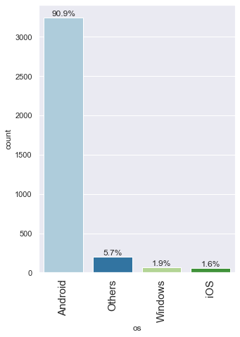

```python
# function to create labelled bar plot
labeled_barplot(df, "os", perc=True)
```

**Observations**

- There are 4 classes of operating systems with Android dominating 91% of the market
- iOS is the smallest class of operating systems

### Let's explore 4g

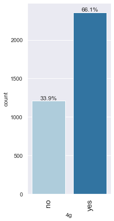

```python
# function to create labelled bar plot
labeled_barplot(df, "4g", perc=True)
```

**Observation**

- 66% of the cellphones in the data base have 4g capability

### Let's explore 5g

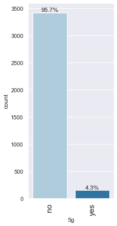

```python
# function to create labelled bar plot
labeled_barplot(df, "5g", perc=True)
```

**Observation**

- Only 4.3% of the phones on the dataset have 5g capability

### Let's explore Internal Memory

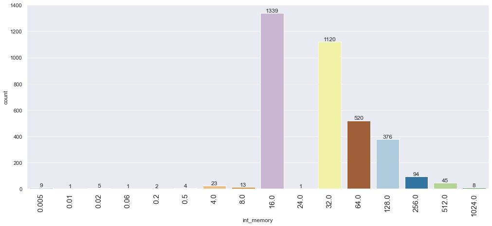

```python
# function to create labelled bar plot
labeled_barplot(df, "int_memory", perc=False)
```

**Observation**

- The largest internal memory class is the `16GB` with 1339 phones in this class.
- This is followed by the `32GB` memory class of wich 1120 phones belong in this class.

### Let's explore release year

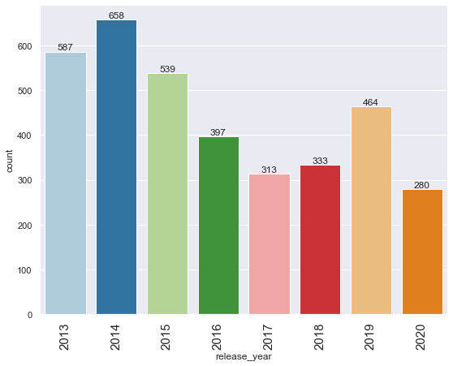

```python
# function to create labelled bar plot
labeled_barplot(df, "release_year", perc=False)
```

**Observation**

### Let's explore ram

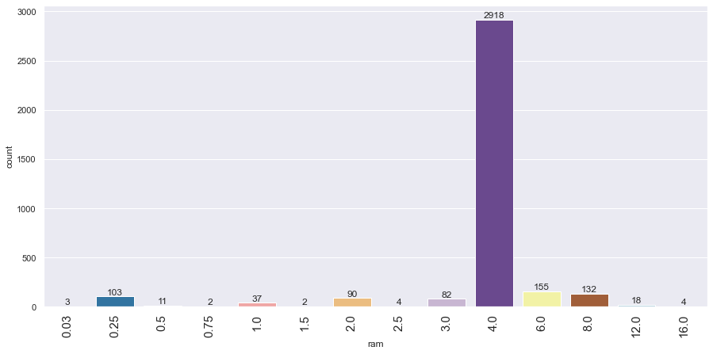

```python
# function to create labelled bar plot
labeled_barplot(df, "ram", perc=False)
```

**Observation**

- The largest ram class appears to be the `4GB` with a count of 2918 phones from the datbase.

### Let's explore Ram vs Brand

```python
df["ram"] = df["ram"].astype(
    "float64"
)  # Temporarily convert ram to a float for mean calculation.
df["brand_name"] = df["brand_name"].astype("category")
df_mean = df.groupby("brand_name")[["ram"]].mean()  # Calculating the mean of ram
df_new = df_mean.reset_index()
df_new.sort_values(
    by=["ram"], ascending=False, inplace=True
)  # sort the values in descending order
df_new
```

|  | brand_name | ram |
| --- | --- | --- |
| 22 | OnePlus | 6.36 |
| 23 | Oppo | 4.96 |
| 30 | Vivo | 4.76 |
| 11 | Huawei | 4.64 |
| 10 | Honor | 4.59 |
| 32 | Xiaomi | 4.57 |
| 8 | Google | 4.53 |
| 17 | Meizu | 4.45 |
| 26 | Realme | 4.20 |
| 27 | Samsung | 4.16 |
| 28 | Sony | 4.07 |
| 3 | Asus | 4.05 |
| 33 | ZTE | 4.02 |
| 9 | HTC | 4.00 |
| 25 | Panasonic | 4.00 |
| 2 | Apple | 4.00 |
| 31 | XOLO | 4.00 |
| 19 | Microsoft | 4.00 |
| 6 | Coolpad | 3.95 |
| 20 | Motorola | 3.95 |
| 7 | Gionee | 3.93 |
| 0 | Acer | 3.90 |
| 14 | LG | 3.89 |
| 16 | Lenovo | 3.89 |
| 4 | BlackBerry | 3.83 |
| 24 | Others | 3.75 |
| 18 | Micromax | 3.75 |
| 29 | Spice | 3.75 |
| 21 | Nokia | 3.60 |
| 1 | Alcatel | 3.43 |
| 13 | Karbonn | 3.38 |
| 15 | Lava | 3.28 |
| 12 | Infinix | 2.60 |
| 5 | Celkon | 1.47 |

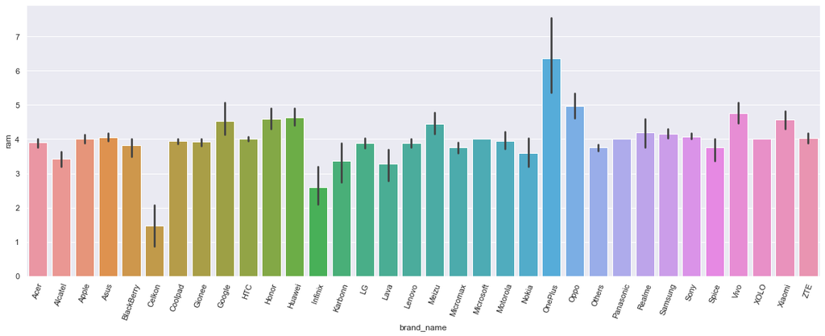

```python
# Here we are plotting cell phone ram vs the brand names to have a visual of the ram distribution across the brands
plt.figure(figsize=(20, 7))
sns.barplot(y=df["ram"], x=df["brand_name"])
plt.xticks(rotation=70)
plt.show()
```

**Observation**

*One plus models have the highest mean ram of all the brands at 6.36 GB

*Oppo models have have the second highest mean ram of all brands at 4.96 GB

```python
# Converting ram back to category
df["ram"] = df["ram"].astype("category")
```

### Let's explore main camera megapixels

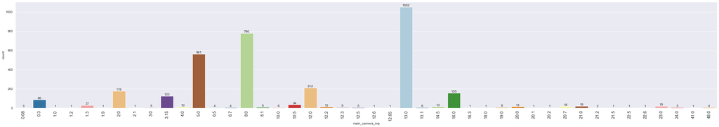

```python
# function to create labelled bar plot
labeled_barplot(df, "main_camera_mp", perc=False)
```

**Observation**

- The `13mp` class appears to be the largest class of main_camera mp in the dataset

### Let's explore selfie camera megapixels

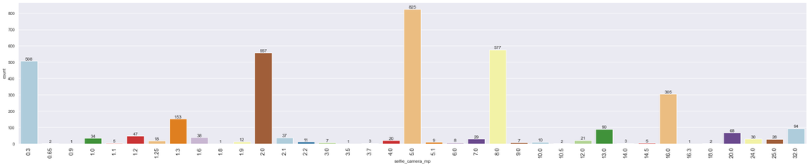

```python
# function to create labelled bar plot
df["selfie_camera_mp"] = df["selfie_camera_mp"].astype("category")
labeled_barplot(df, "selfie_camera_mp", perc=False)
```

**Observation**

- The `5mp` class appears to be the largest class of the selfie_camera mp in the dataset

## Data Preprocessing

- Missing value treatment
- Duplicate value check
- Feature engineering (if needed)
- Outlier detection and treatment (if needed)
- Preparing data for modeling
- Any other preprocessing steps (if needed)

### Duplicate value check

```python
# looking at which values are duplicated
duplicate = df[df.duplicated()]
print("Duplicated Rows:")
duplicate.sum()
```

```
Duplicated Rows:
```

```
os            0.00
screen_size   0.00
4g            0.00
5g            0.00
battery       0.00
weight        0.00
days_used     0.00
new_price     0.00
used_price    0.00
dtype: float64
```

**Observation**

- There are no duplicated rows

### Missing Values treatment

#### Let's look at which columns have the most missing values

```python
# looking at which columns have the most missing values
df.isnull().sum().sort_values(ascending=False)
```

```
main_camera_mp      180
int_memory           10
ram                  10
weight                7
battery               6
selfie_camera_mp      2
brand_name            0
os                    0
screen_size           0
4g                    0
5g                    0
release_year          0
days_used             0
new_price             0
used_price            0
dtype: int64
```

```python
# counting the number of missing values per row
df.isnull().sum(axis=1).value_counts()
```

```
0    3368
1     193
2       8
3       2
dtype: int64
```

```python
# Let's investigate the rows that are missing 1, 2 and 3 values.
num_missing = df.isnull().sum(axis=1)
num_missing.value_counts()
```

```
0    3368
1     193
2       8
3       2
dtype: int64
```

```python
# these are missing main_camera_mp
df[num_missing == 1].sample(n=5)
```

|  | brand_name | os | screen_size | 4g | 5g | main_camera_mp | selfie_camera_mp | int_memory | ram | battery | weight | release_year | days_used | new_price | used_price |
| --- | --- | --- | --- | --- | --- | --- | --- | --- | --- | --- | --- | --- | --- | --- | --- |
| 349 | OnePlus | Android | 25.88 | yes | yes | NaN | 16.00 | 256.00 | 12.00 | 4085.00 | 206.00 | 2019 | 280 | 800.92 | 553.59 |
| 288 | Infinix | Android | 16.19 | yes | no | NaN | 16.00 | 32.00 | 3.00 | 4000.00 | 178.00 | 2019 | 356 | 100.08 | 63.94 |
| 99 | Meizu | Android | 16.19 | yes | yes | NaN | 20.00 | 128.00 | 8.00 | 4500.00 | 199.00 | 2020 | 186 | 529.55 | 398.56 |
| 2291 | Panasonic | Android | 18.26 | yes | no | NaN | 8.00 | 64.00 | 4.00 | 4000.00 | 169.00 | 2018 | 487 | 199.08 | 99.55 |
| 417 | Coolpad | Android | 23.65 | yes | yes | NaN | 16.00 | 64.00 | 4.00 | 4000.00 | 195.00 | 2020 | 252 | 359.77 | 258.53 |

```python
# these are missing `int_memory` and `ram`
df[num_missing == 2].sample(n=5)
```

|  | brand_name | os | screen_size | 4g | 5g | main_camera_mp | selfie_camera_mp | int_memory | ram | battery | weight | release_year | days_used | new_price | used_price |
| --- | --- | --- | --- | --- | --- | --- | --- | --- | --- | --- | --- | --- | --- | --- | --- |
| 2148 | Nokia | Others | 5.72 | no | no | 0.30 | 2.00 | NaN | NaN | 1100.00 | 78.40 | 2015 | 559 | 29.33 | 14.76 |
| 2149 | Nokia | Others | 5.72 | no | no | 0.30 | 2.00 | NaN | NaN | 1100.00 | 78.60 | 2015 | 682 | 30.00 | 12.03 |
| 2146 | Nokia | Others | 3.18 | no | no | 2.00 | 2.00 | NaN | NaN | 800.00 | 69.60 | 2015 | 1009 | 19.92 | 6.07 |
| 2142 | Nokia | Others | 6.35 | no | no | 2.00 | 2.00 | NaN | NaN | 1200.00 | 91.80 | 2015 | 867 | 68.01 | 20.46 |
| 2145 | Nokia | Others | 5.72 | no | no | 2.00 | 2.00 | NaN | NaN | 1100.00 | 79.00 | 2015 | 798 | 40.48 | 16.13 |

```python
# these are missing `int_memory`, `ram`and 'battery'
df[num_missing == 3].sample(n=2)
```

|  | brand_name | os | screen_size | 4g | 5g | main_camera_mp | selfie_camera_mp | int_memory | ram | battery | weight | release_year | days_used | new_price | used_price |
| --- | --- | --- | --- | --- | --- | --- | --- | --- | --- | --- | --- | --- | --- | --- | --- |
| 2141 | Nokia | Others | 5.72 | no | no | 0.30 | 0.30 | NaN | NaN | NaN | 82.60 | 2016 | 1023 | 38.78 | 11.42 |
| 2140 | Nokia | Others | 5.72 | no | no | 0.30 | 0.30 | NaN | NaN | NaN | 81.00 | 2016 | 815 | 29.21 | 8.65 |

Observation

#### As most of the data above is skewed, we will fill in the missing values usind the respective `Median' values.

It appears the missing values are structered, so we can use a loop to investigate further

```python
for n in num_missing.value_counts().sort_index().index:
    if n > 0:
        print(f"For the rows with exactly {n} missing values, NAs are found in:")
        n_miss_per_col = df[num_missing == n].isnull().sum()
        print(n_miss_per_col[n_miss_per_col > 0])
        print("\n\n")
```

```
For the rows with exactly 1 missing values, NAs are found in:
main_camera_mp      180
selfie_camera_mp      2
battery               4
weight                7
dtype: int64



For the rows with exactly 2 missing values, NAs are found in:
int_memory    8
ram           8
dtype: int64



For the rows with exactly 3 missing values, NAs are found in:
int_memory    2
ram           2
battery       2
dtype: int64
```

### Filling in with a standard value

```python
# Code to determine the median values of the predictors in the data set (numeric values)
df.median()
```

```
screen_size     13.49
battery       3000.00
weight         159.00
days_used      690.00
new_price      189.80
used_price      75.53
dtype: float64
```

```python
medianFiller = lambda x: x.fillna(x.median())
numeric_columns = df.select_dtypes(include=np.number).columns.tolist()
df[numeric_columns] = df[numeric_columns].apply(medianFiller, axis=0)
```

```python
# Verifying the numeric columns before proceeding
numeric_columns
```

```
['screen_size', 'battery', 'weight', 'days_used', 'new_price', 'used_price']
```

```python
# checking the number of missing values
df.isnull().sum()
```

```
brand_name            0
os                    0
screen_size           0
4g                    0
5g                    0
main_camera_mp      180
selfie_camera_mp      2
int_memory           10
ram                  10
battery               0
weight                0
release_year          0
days_used             0
new_price             0
used_price            0
dtype: int64
```

### Bivariate Analysis

#### Let's look at the graphs of a few variables that are highly correlated with Used_Price

#### used_price vs ram vs 5g

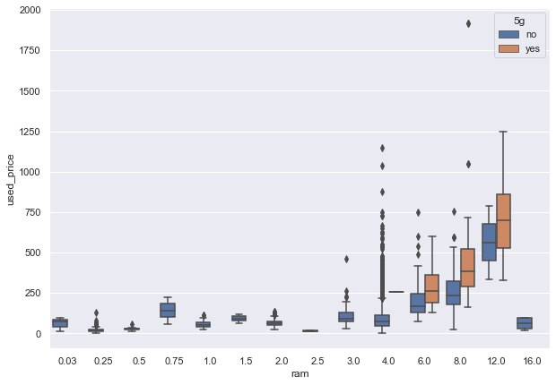

```python
plt.figure(figsize=(10, 7))
sns.boxplot(y="used_price", x="ram", hue="5g", data=df)
plt.show()
```

**Observation**

- Phones with 6GB upwards appear to have `5g` optionality. These phones can fetch prices from 250 to as high as 1250 euros.
- Phones with 0.03 GB to 4 GB do not appear to have `5g` optionality. Max Prices for most of these phones are around 250 euros.
- Phones with 4GB ram appear to have a lot of outliers above 250 euros going as high as 1250 euros

#### used_price vs ram vs 4g

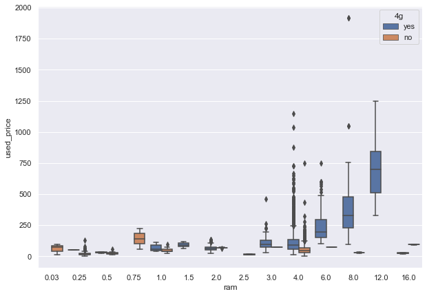

```python
plt.figure(figsize=(10, 7))
sns.boxplot(y="used_price", x="ram", hue="4g", data=df)
plt.show()
```

**Observation**

- Phones above 1GB ram appear to have `4g` capability.
- Most of these phones up to 2.5 GB ram are priced below 250 euros.
- Phones 3.0 GB ram upwards with `4g` capability can fetch prices from 250 - 1250 euros, with higher ram phones fetching the higher prices.
- Phones with 4GB ram appear to have a lot of outliers above 250 euros going as high as 1250 euros

#### used price vs release_year vs 5g

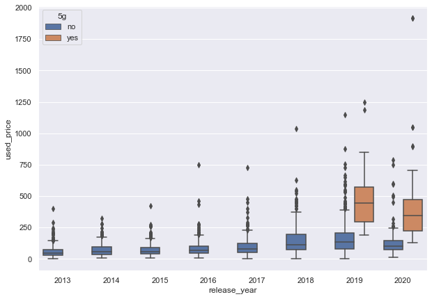

```python
plt.figure(figsize=(10, 7))
sns.boxplot(y="used_price", x="release_year", hue="5g", data=df)
plt.show()
```

Observations

- All release years appear to have outliers.
- For phones without 5g capability, the median prices for all are close and below 250 euros
- Phones with 5 g capability are available with 2019 and 2020 models with median prices aroung 400 euros
- Models from 2013 to 2018 do not appear to have 5g capability

#### used price vs release_year vs 4g

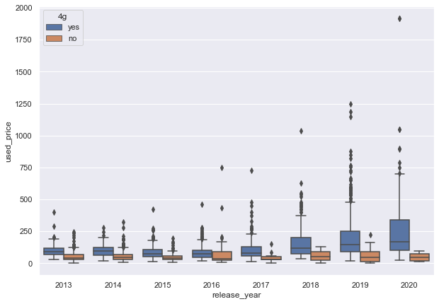

```python
plt.figure(figsize=(10, 7))
sns.boxplot(y="used_price", x="release_year", hue="4g", data=df)
plt.show()
```

Observations

- All release year models from 2013 to 2020 have 4g capability
- All release years have outliers
- from 2013 to 2017 with the exception of the outliers, the upper limit appears to be around 250 euros
- The median prices of phones `without` regardless of the release years appears to be below 125 euros
- With the `exception of outliers`, phones from `release years` `2018` to `2019` have max prices ranging from around `400 euros` to `750 euros`

**Median *used_price* by *release_year* and *5g***

```python
# Here we are sorting the brand names by mean ram values in descending order
df_mean.sort_values(by=["ram"], ascending=False, inplace=False)
```

| brand_name | ram |
| --- | --- |
| OnePlus | 6.36 |
| Oppo | 4.96 |
| Vivo | 4.76 |
| Huawei | 4.64 |
| Honor | 4.59 |
| Xiaomi | 4.57 |
| Google | 4.53 |
| Meizu | 4.45 |
| Realme | 4.20 |
| Samsung | 4.16 |
| Sony | 4.07 |
| Asus | 4.05 |
| ZTE | 4.02 |
| HTC | 4.00 |
| Panasonic | 4.00 |
| Apple | 4.00 |
| XOLO | 4.00 |
| Microsoft | 4.00 |
| Coolpad | 3.95 |
| Motorola | 3.95 |
| Gionee | 3.93 |
| Acer | 3.90 |
| LG | 3.89 |
| Lenovo | 3.89 |
| BlackBerry | 3.83 |
| Others | 3.75 |
| Micromax | 3.75 |
| Spice | 3.75 |
| Nokia | 3.60 |
| Alcatel | 3.43 |
| Karbonn | 3.38 |
| Lava | 3.28 |
| Infinix | 2.60 |
| Celkon | 1.47 |

```python
# Here we are resetting the index so we make 'brand_name' a column available for the plots
df_mean.reset_index()
```

|  | brand_name | ram |
| --- | --- | --- |
| 0 | Acer | 3.90 |
| 1 | Alcatel | 3.43 |
| 2 | Apple | 4.00 |
| 3 | Asus | 4.05 |
| 4 | BlackBerry | 3.83 |
| 5 | Celkon | 1.47 |
| 6 | Coolpad | 3.95 |
| 7 | Gionee | 3.93 |
| 8 | Google | 4.53 |
| 9 | HTC | 4.00 |
| 10 | Honor | 4.59 |
| 11 | Huawei | 4.64 |
| 12 | Infinix | 2.60 |
| 13 | Karbonn | 3.38 |
| 14 | LG | 3.89 |
| 15 | Lava | 3.28 |
| 16 | Lenovo | 3.89 |
| 17 | Meizu | 4.45 |
| 18 | Micromax | 3.75 |
| 19 | Microsoft | 4.00 |
| 20 | Motorola | 3.95 |
| 21 | Nokia | 3.60 |
| 22 | OnePlus | 6.36 |
| 23 | Oppo | 4.96 |
| 24 | Others | 3.75 |
| 25 | Panasonic | 4.00 |
| 26 | Realme | 4.20 |
| 27 | Samsung | 4.16 |
| 28 | Sony | 4.07 |
| 29 | Spice | 3.75 |
| 30 | Vivo | 4.76 |
| 31 | XOLO | 4.00 |
| 32 | Xiaomi | 4.57 |
| 33 | ZTE | 4.02 |

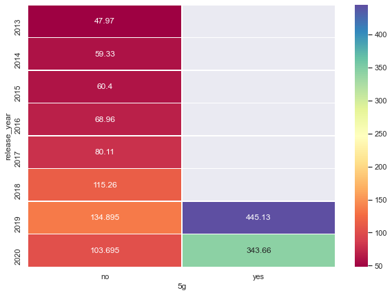

```python
# Here we are creating a pivot table so we can analyse the median used prices of 5g phones by release year
df_hm = df.pivot_table(
    index="release_year",
    columns="5g",
    values="used_price",
    aggfunc=np.median,

)

# Draw a heatmap
f, ax = plt.subplots(figsize=(10, 7))
sns.heatmap(df_hm, cmap="Spectral", linewidths=0.5, annot=True, ax=ax, fmt ='g')
plt.show()
```

Observation

- Without 5g, model prices range from 48 - 104 euros from 2013 to 2020 respectively.
- There are no 5g models prior to 2019
- 5g models median prices are 445 to 343 euros from 2019 to 2020 respectively.
- There was a drop in the median prices of 5g from 2019 to 2020.

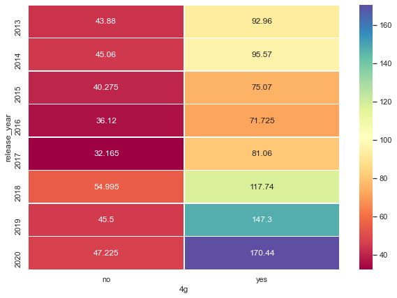

```python
# Here we are creating a pivot table so we can analyse the median used prices of 4g phones by release year
df_hm = df.pivot_table(
    index="release_year",
    columns="4g",
    values="used_price",
    aggfunc=np.median,

)

# Draw a heatmap
f, ax = plt.subplots(figsize=(10, 7))
sns.heatmap(df_hm, cmap="Spectral", linewidths=0.5, annot=True, ax=ax, fmt ='g')
plt.show()
```

Observation

```python
# lets define a variable numeric columns
numeric_columns = df.select_dtypes(include=np.number).columns.tolist()
numeric_columns
```

```
['screen_size', 'battery', 'weight', 'days_used', 'new_price', 'used_price']
```

**Let's look at correlations.**

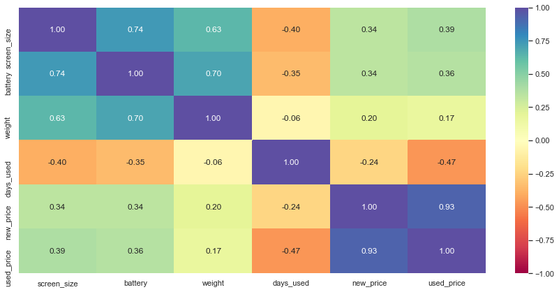

```python
# correlation heatmap
plt.figure(figsize=(15, 7))
sns.heatmap(
    df[numeric_columns].corr(), annot=True, vmin=-1, vmax=1, fmt=".2f", cmap="Spectral",
)
plt.show()
```

**Observations**

- `New` and `used` prices are positively correlated with `screen_size`,`battery` and`weight`.
- `New` and `used` prices are negatively correlated with `days_used`
- `used_price` is negatively correlated with `days_used`
- We are seeing high positive correlations between some of the independent variables such as battery_vs screen_size and weight.
- This means as these variable increases the other variable increases. e.g higher battery capacity would result in an increase in weight of the phone.
- For the negative correlations as these variable increases, the other variable decreases. e.g days used would negativel affect used prices
- High correlation between the predictors will affect the predictive value of the regression models, but this will be analyzed later on.

```python
# Let's create a dataframe df2 that only contains numeric columns except used_prices_log.
# This is done because we do not want to do outlier treatment on the log transformed used_prices_log

numeric_columns = df.select_dtypes(include=np.number).columns.tolist()
numeric_columns
```

```
['screen_size', 'battery', 'weight', 'days_used', 'new_price', 'used_price']
```

### Outlier Detection

- Let's look at outliers in every numerical column

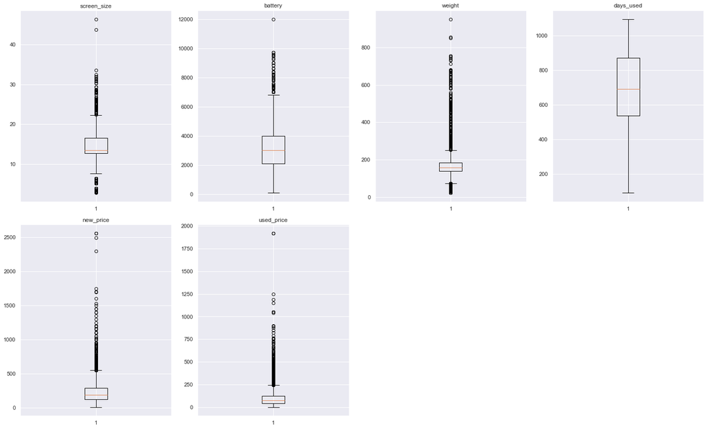

```python
# let's plot the boxplots of all columns to check for outliers
plt.figure(figsize=(20, 30))

for i, variable in enumerate(numeric_columns):
    plt.subplot(5, 4, i + 1)
    plt.boxplot(df[variable], whis=1.5)
    plt.tight_layout()
    plt.title(variable)

plt.show()
```

**Observations**

- There are upper and lower outliers in `screen_size` and `weight`.
- There are upper outliers alone in `new_price`.
- There are no outliers in `days_used`.
- We will treat these outliers as these might adversely affect the predictive power of linear model. However, in real life, these outliers may be due to non-linear pattern in the data or can be important information.
- Sometimes outliers in the independent variable can adversely impact the linear model. This can be checked by building the model with and without outliers and comparing the model performances.

### Outlier Treatment

- Let's treat outliers in the data by flooring and capping.

```python
def treat_outliers(df, col):
    """
    treats outliers in a variable
    col: str, name of the numerical variable
    df: dataframe
    col: name of the column
    """
    Q1 = df[col].quantile(0.25)  # 25th quantile
    Q3 = df[col].quantile(0.75)  # 75th quantile
    IQR = Q3 - Q1
    Lower_Whisker = Q1 - 1.5 * IQR
    Upper_Whisker = Q3 + 1.5 * IQR

    # all the values smaller than Lower_Whisker will be assigned the value of Lower_Whisker
    # all the values greater than Upper_Whisker will be assigned the value of Upper_Whisker
    df[col] = np.clip(df[col], Lower_Whisker, Upper_Whisker)

    return df


def treat_outliers_all(df, col_list):
    """
    treat outlier in all numerical variables
    col_list: list of numerical variables
    df: data frame
    """
    for c in col_list:
        df = treat_outliers(df, c)

    return df
```

```python
# treating the outliers
numerical_col = df.select_dtypes(include=np.number).columns.tolist()
df = treat_outliers_all(df, numerical_col)
```

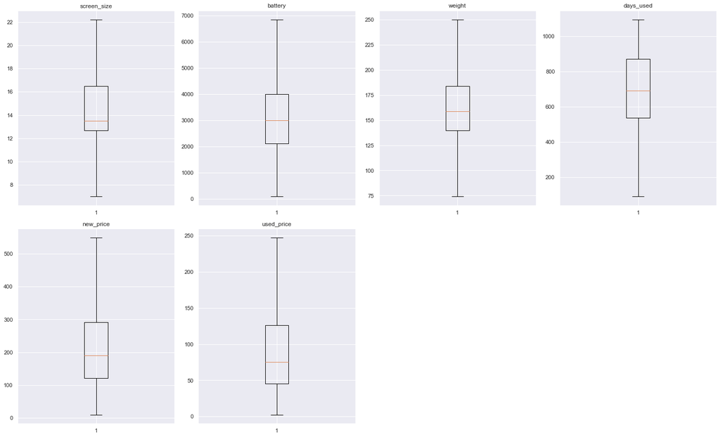

```python
# let's look at the boxplots to see if the outliers have been treated or not
plt.figure(figsize=(20, 30))

for i, variable in enumerate(numeric_columns):
    plt.subplot(5, 4, i + 1)
    plt.boxplot(df[variable], whis=1.5)
    plt.tight_layout()
    plt.title(variable)

plt.show()
```

**Observations**

*All outliers have been successfully treated.

```python
### Let's add back used_price_log to the dataframe to continue the analysis

df.columns
```

```
Index(['brand_name', 'os', 'screen_size', '4g', '5g', 'main_camera_mp',
       'selfie_camera_mp', 'int_memory', 'ram', 'battery', 'weight',
       'release_year', 'days_used', 'new_price', 'used_price'],
      dtype='object')
```

## EDA

- It is a good idea to explore the data once again after manipulating it.

#### Let's look at the graphs of a few variables that are highly correlated with Used_Price

```python
# verification check that all columns have the appropriate columns
df.columns
```

```
Index(['brand_name', 'os', 'screen_size', '4g', '5g', 'main_camera_mp',
       'selfie_camera_mp', 'int_memory', 'ram', 'battery', 'weight',
       'release_year', 'days_used', 'new_price', 'used_price'],
      dtype='object')
```

#### used_price vs ram

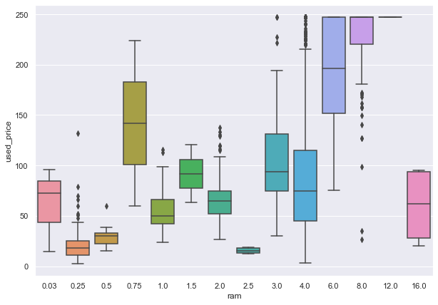

```python
plt.figure(figsize=(10, 7))
sns.boxplot(y="used_price", x="ram", data=df)
plt.show()
```

**Observation**

- Used prices for all phones have been replaced by the median value of 4GB
- The upper and lower limits of outliers have been capped (this is aggregation of both 4G and 5G)

#### used price vs release_year vs 5g

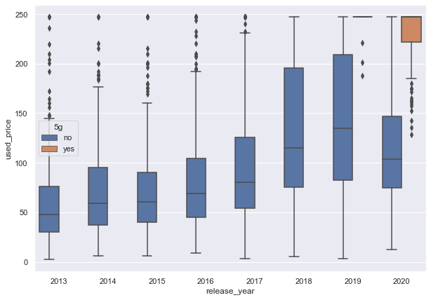

```python
plt.figure(figsize=(10, 7))
sns.boxplot(y="used_price", x="release_year", hue="5g", data=df)
plt.show()
```

**Observation**

- All outliers have been efficiently capped.
- 2019 and 2020 5g prices were around `750` at the upper whisker limit `prior to capping`. Now it has been capped at `250`.
- This capping may affect the ability to predict prices of used 5G phones

#### used price vs release_year vs 4g

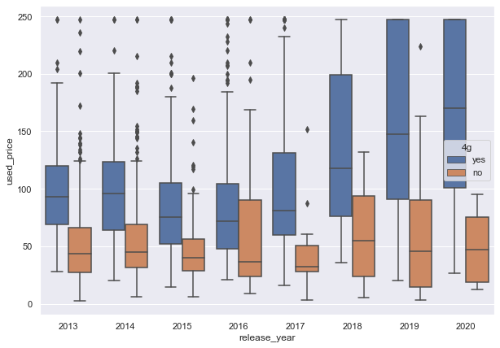

```python
plt.figure(figsize=(10, 7))
sns.boxplot(y="used_price", x="release_year", hue="4g", data=df)
plt.show()
```

**Observations**

- Once again the upper limits are capped at 250 euros.
- Before capping, 2019 and 2020 4g prices upper limit whiskers were at around 500 euros and 750 euros respectively
- The capping may affect the models ability to predict prices of 2019 and 2020 4g models accurately

## Building a Linear Regression model

## Linear Model Building

1. We want to predict the prices of used cellphones and factors that affect it signicantly
2. Before we proceed to build a model, we'll have to encode categorical features.
3. We'll split the data into train and test to be able to evaluate the model that we build on the train data.
4. We will build a Linear Regression model using the train data and then check it's performance.

### Let's have a look at the categorical variables again

```python
df["main_camera_mp"].unique().value_counts().sum()
```

```
44
```

```python
df["selfie_camera_mp"].unique().value_counts().sum()
```

```
37
```

```python
df["int_memory"].unique().value_counts().sum()
```

```
16
```

```python
df["4g"].value_counts()
```

```
yes    2359
no     1212
Name: 4g, dtype: int64
```

```python
df["5g"].value_counts()
```

```
no     3419
yes     152
Name: 5g, dtype: int64
```

```python
df["release_year"].unique().value_counts().sum()
```

```
8
```

```python
df["os"].unique()
```

```
array(['Android', 'Others', 'iOS', 'Windows'], dtype=object)
```

```python
df["brand_name"].unique()
```

```
['Honor', 'Others', 'HTC', 'Huawei', 'Infinix', ..., 'Microsoft', 'Panasonic', 'Sony', 'Spice', 'XOLO']
Length: 34
Categories (34, object): ['Honor', 'Others', 'HTC', 'Huawei', ..., 'Panasonic', 'Sony', 'Spice', 'XOLO']
```

```python
df["screen_size"].value_counts()
```

```
12.70    576
13.49    409
22.23    390
10.95    219
10.16    189
        ...
11.91      1
9.84       1
10.32      1
14.60      1
10.80      1
Name: screen_size, Length: 75, dtype: int64
```

**Observation**

- `battery` can have as many as `354` types
- `main_camera_mp` has `44` sizes
- `selfie_camera_mp` has `37` sizes
- `int_memory` has 16 sizes
- `4g` has two options `yes` or `no`
- `5g` has two options `yes` or `no`
- `os` has 4 options
- `screen_size` has 75 sizes

### Too many categorical features creates issues for the modelling

- Objective is to build a model to predicted use prices
- Minimize RMSE
- Adj R2 will be used as an additional gauge to determine which predictors are adding value
- We will create a dataframe that has all the numeric variables and add categoricals that have minimal categories.
- From the observations above, we will only include `4g`, `5g`,`os`and `release_year` as categoricals in the train and test data.
- If the `residuals` are too high impacting `predicted` vs `actual` used prices, we can add additional categories.

```python
df.columns
```

```
Index(['brand_name', 'os', 'screen_size', '4g', '5g', 'main_camera_mp',
       'selfie_camera_mp', 'int_memory', 'ram', 'battery', 'weight',
       'release_year', 'days_used', 'new_price', 'used_price'],
      dtype='object')
```

```python
df1 = df[["os", "4g", "5g", "release_year", "new_price", "used_price", "days_used"]]
```

```python
# defining X and y variables
X = df1.drop(["used_price"], axis=1)
y = df1["used_price"]

print(X.head())
print(y.head())
```

```
        os   4g   5g release_year  new_price  days_used
0  Android  yes   no         2020     111.62        127
1  Android  yes  yes         2020     249.39        325
2  Android  yes  yes         2020     359.47        162
3  Android  yes  yes         2020     278.93        345
4  Android  yes   no         2020     140.87        293
0    86.96
1   161.49
2   247.19
3   180.23
4   103.80
Name: used_price, dtype: float64
```

```python
X = pd.get_dummies(
    X,
    columns=X.select_dtypes(include=["object", "category"]).columns.tolist(),
    drop_first=True,
)
X.head()
```

|  | new_price | days_used | os_Others | os_Windows | os_iOS | 4g_yes | 5g_yes | release_year_2014 | release_year_2015 | release_year_2016 | release_year_2017 | release_year_2018 | release_year_2019 | release_year_2020 |
| --- | --- | --- | --- | --- | --- | --- | --- | --- | --- | --- | --- | --- | --- | --- |
| 0 | 111.62 | 127 | 0 | 0 | 0 | 1 | 0 | 0 | 0 | 0 | 0 | 0 | 0 | 1 |
| 1 | 249.39 | 325 | 0 | 0 | 0 | 1 | 1 | 0 | 0 | 0 | 0 | 0 | 0 | 1 |
| 2 | 359.47 | 162 | 0 | 0 | 0 | 1 | 1 | 0 | 0 | 0 | 0 | 0 | 0 | 1 |
| 3 | 278.93 | 345 | 0 | 0 | 0 | 1 | 1 | 0 | 0 | 0 | 0 | 0 | 0 | 1 |
| 4 | 140.87 | 293 | 0 | 0 | 0 | 1 | 0 | 0 | 0 | 0 | 0 | 0 | 0 | 1 |

```python
# splitting the data in 70:30 ratio for train to test data

x_train, x_test, y_train, y_test = train_test_split(
    X, y, test_size=0.3, random_state=42
)
```

```python
print("Number of rows in train data =", x_train.shape[0])
print("Number of rows in test data =", x_test.shape[0])
```

```
Number of rows in train data = 2499
Number of rows in test data = 1072
```

```python
# fitting the model on the train data (70% of the whole data)
from sklearn.linear_model import LinearRegression

linearregression = LinearRegression()
linearregression.fit(x_train, y_train)
```

```
LinearRegression()
```

**Let's check the coefficients and intercept of the model.**

```python
coef_df = pd.DataFrame(
    np.append(linearregression.coef_, linearregression.intercept_),
    index=x_train.columns.tolist() + ["Intercept"],
    columns=["Coefficients"],
)

coef_df
```

|  | Coefficients |
| --- | --- |
| new_price | 0.40 |
| days_used | -0.08 |
| os_Others | -3.59 |
| os_Windows | -1.63 |
| os_iOS | 2.81 |
| 4g_yes | -2.65 |
| 5g_yes | 7.42 |
| release_year_2014 | -0.85 |
| release_year_2015 | -0.87 |
| release_year_2016 | 0.61 |
| release_year_2017 | -0.99 |
| release_year_2018 | 6.05 |
| release_year_2019 | 12.69 |
| release_year_2020 | 6.84 |
| Intercept | 61.71 |

## Model performance evaluation

**Let's check the performance of the model using different metrics.**

- We will be using metric functions defined in sklearn for RMSE, MAE, and $R^2$.
- We will define a function to calculate MAPE and adjusted $R^2$.
  - The mean absolute percentage error (MAPE) measures the accuracy of predictions as a percentage, and can be calculated as the average absolute percent error for each predicted value minus actual values divided by actual values. It works best if there are no extreme values in the data and none of the actual values are 0.
- We will create a function which will print out all the above metrics in one go.

```python
# function to compute adjusted R-squared
def adj_r2_score(predictors, targets, predictions):
    r2 = r2_score(targets, predictions)
    n = predictors.shape[0]
    k = predictors.shape[1]
    return 1 - ((1 - r2) * (n - 1) / (n - k - 1))


# function to compute MAPE
def mape_score(targets, predictions):
    return np.mean(np.abs(targets - predictions) / targets) * 100


# function to compute different metrics to check performance of a regression model
def model_performance_regression(model, predictors, target):
    """
    Function to compute different metrics to check regression model performance

    model: regressor
    predictors: independent variables
    target: dependent variable
    """

    # predicting using the independent variables
    pred = model.predict(predictors)

    r2 = r2_score(target, pred)  # to compute R-squared
    adjr2 = adj_r2_score(predictors, target, pred)  # to compute adjusted R-squared
    rmse = np.sqrt(mean_squared_error(target, pred))  # to compute RMSE
    mae = mean_absolute_error(target, pred)  # to compute MAE
    mape = mape_score(target, pred)  # to compute MAPE

    # creating a dataframe of metrics
    df_perf = pd.DataFrame(
        {
            "RMSE": rmse,
            "MAE": mae,
            "R-squared": r2,
            "Adj. R-squared": adjr2,
            "MAPE": mape,
        },
        index=[0],
    )

    return df_perf
```

```python
# checking model performance on train set (seen 70% data)
print("Training Performance\n")
linearregression_train_perf = model_performance_regression(
    linearregression, x_train, y_train
)
linearregression_train_perf
```

```
Training Performance
```

|  | RMSE | MAE | R-squared | Adj. R-squared | MAPE |
| --- | --- | --- | --- | --- | --- |
| 0 | 14.52 | 10.59 | 0.95 | 0.95 | 19.68 |

```python
# checking model performance on test set (seen 30% data)
print("Test Performance\n")
linearregression_test_perf = model_performance_regression(
    linearregression, x_test, y_test
)
linearregression_test_perf
```

```
Test Performance
```

|  | RMSE | MAE | R-squared | Adj. R-squared | MAPE |
| --- | --- | --- | --- | --- | --- |
| 0 | 14.41 | 10.51 | 0.95 | 0.95 | 16.88 |

**Observations**

## Linear Regression using statsmodels

- Let's build a linear regression model using statsmodels.

```python
# unlike sklearn, statsmodels does not add a constant to the data on its own
# we have to add the constant manually
x_train1 = sm.add_constant(x_train)
# adding constant to the test data
x_test1 = sm.add_constant(x_test)

olsmod0 = sm.OLS(y_train, x_train1).fit()
print(olsmod0.summary())
```

```
                            OLS Regression Results
==============================================================================
Dep. Variable:             used_price   R-squared:                       0.951
Model:                            OLS   Adj. R-squared:                  0.951
Method:                 Least Squares   F-statistic:                     3477.
Date:                Sat, 23 Oct 2021   Prob (F-statistic):               0.00
Time:                        02:05:01   Log-Likelihood:                -10233.
No. Observations:                2499   AIC:                         2.050e+04
Df Residuals:                    2484   BIC:                         2.058e+04
Df Model:                          14
Covariance Type:            nonrobust
=====================================================================================
                        coef    std err          t      P>|t|      [0.025      0.975]
-------------------------------------------------------------------------------------
const                61.7105      1.928     32.002      0.000      57.929      65.492
new_price             0.3990      0.003    148.139      0.000       0.394       0.404
days_used            -0.0821      0.002    -39.432      0.000      -0.086      -0.078
os_Others            -3.5859      1.286     -2.788      0.005      -6.108      -1.064
os_Windows           -1.6336      2.151     -0.760      0.448      -5.851       2.584
os_iOS                2.8125      2.495      1.127      0.260      -2.079       7.704
4g_yes               -2.6517      0.882     -3.008      0.003      -4.380      -0.923
5g_yes                7.4216      1.884      3.940      0.000       3.728      11.116
release_year_2014    -0.8497      0.995     -0.854      0.393      -2.801       1.101
release_year_2015    -0.8656      1.124     -0.770      0.441      -3.070       1.339
release_year_2016     0.6053      1.282      0.472      0.637      -1.909       3.119
release_year_2017    -0.9938      1.388     -0.716      0.474      -3.715       1.728
release_year_2018     6.0539      1.458      4.153      0.000       3.195       8.912
release_year_2019    12.6874      1.591      7.975      0.000       9.568      15.807
release_year_2020     6.8445      1.977      3.462      0.001       2.968      10.721
==============================================================================
Omnibus:                      231.563   Durbin-Watson:                   1.964
Prob(Omnibus):                  0.000   Jarque-Bera (JB):              469.006
Skew:                           0.599   Prob(JB):                    1.43e-102
Kurtosis:                       4.752   Cond. No.                     8.37e+03
==============================================================================

Notes:
[1] Standard Errors assume that the covariance matrix of the errors is correctly specified.
[2] The condition number is large, 8.37e+03. This might indicate that there are
strong multicollinearity or other numerical problems.
```

**Observations**

- Negative values of the coefficient show that `used_prices` decreases with the increase of corresponding variable.
- Positive values of the coefficient show that `used_prices` increases with the increase of corresponding variable.
- p-value of a variable indicates if the variable is significant or not. If we consider the significance level to be 0.05 (5%), then any variable with a p-value less than 0.05 would be considered significant.
- But these variables might contain multicollinearity, which will affect the p-values.
- So, we need to deal with multicollinearity and check the other assumptions of linear regression first, and then look at the p-values.

## Checking Linear Regression Assumptions

- In order to make statistical inferences from a linear regression model, it is important to ensure that the assumptions of linear regression are satisfied.

We will be checking the following Linear Regression assumptions:

1. **No Multicollinearity**
2. **Linearity of variables**
3. **Independence of error terms**
4. **Normality of error terms**
5. **No Heteroscedasticity**

### TEST FOR MULTICOLLINEARITY

- Multicollinearity occurs when predictor variables in a regression model are correlated. This correlation is a problem because predictor variables should be independent. If the correlation between variables is high, it can cause problems when we fit the model and interpret the results. When we have multicollinearity in the linear model, the coefficients that the model suggests are unreliable.
- There are different ways of detecting (or testing) multicollinearity. One such way is by using the Variance Inflation Factor, or VIF.
- **Variance Inflation Factor (VIF)**: Variance inflation factors measure the inflation in the variances of the regression parameter estimates due to collinearities that exist among the predictors. It is a measure of how much the variance of the estimated regression coefficient $\beta_k$ is "inflated" by the existence of correlation among the predictor variables in the model.
  - If VIF is 1, then there is no correlation among the $k$th predictor and the remaining predictor variables, and hence, the variance of $\beta_k$ is not inflated at all.
- **General Rule of thumb**:
  - If VIF is between 1 and 5, then there is low multicollinearity.
  - If VIF is between 5 and 10, we say there is moderate multicollinearity.
  - If VIF is exceeding 10, it shows signs of high multicollinearity.

```python
from statsmodels.stats.outliers_influence import variance_inflation_factor

# we will define a function to check VIF
def checking_vif(predictors):
    vif = pd.DataFrame()
    vif["feature"] = predictors.columns

    # calculating VIF for each feature
    vif["VIF"] = [
        variance_inflation_factor(predictors.values, i)
        for i in range(len(predictors.columns))
    ]
    return vif
```

```python
checking_vif(x_train1)
```

|  | feature | VIF |
| --- | --- | --- |
| 0 | const | 43.79 |
| 1 | new_price | 1.56 |
| 2 | days_used | 3.21 |
| 3 | os_Others | 1.11 |
| 4 | os_Windows | 1.03 |
| 5 | os_iOS | 1.07 |
| 6 | 4g_yes | 2.07 |
| 7 | 5g_yes | 1.65 |
| 8 | release_year_2014 | 1.81 |
| 9 | release_year_2015 | 1.85 |
| 10 | release_year_2016 | 1.86 |
| 11 | release_year_2017 | 1.83 |
| 12 | release_year_2018 | 2.22 |
| 13 | release_year_2019 | 3.21 |
| 14 | release_year_2020 | 3.51 |

**Observation**

- No VIF values are greater than 5.
- We can proceed with using this data set to finalize the model

Let's check the model performance.

```python
olsmod0 = sm.OLS(y_train, x_train1).fit()
print(olsmod0.summary())
```

```
                            OLS Regression Results
==============================================================================
Dep. Variable:             used_price   R-squared:                       0.951
Model:                            OLS   Adj. R-squared:                  0.951
Method:                 Least Squares   F-statistic:                     3477.
Date:                Sat, 23 Oct 2021   Prob (F-statistic):               0.00
Time:                        02:05:02   Log-Likelihood:                -10233.
No. Observations:                2499   AIC:                         2.050e+04
Df Residuals:                    2484   BIC:                         2.058e+04
Df Model:                          14
Covariance Type:            nonrobust
=====================================================================================
                        coef    std err          t      P>|t|      [0.025      0.975]
-------------------------------------------------------------------------------------
const                61.7105      1.928     32.002      0.000      57.929      65.492
new_price             0.3990      0.003    148.139      0.000       0.394       0.404
days_used            -0.0821      0.002    -39.432      0.000      -0.086      -0.078
os_Others            -3.5859      1.286     -2.788      0.005      -6.108      -1.064
os_Windows           -1.6336      2.151     -0.760      0.448      -5.851       2.584
os_iOS                2.8125      2.495      1.127      0.260      -2.079       7.704
4g_yes               -2.6517      0.882     -3.008      0.003      -4.380      -0.923
5g_yes                7.4216      1.884      3.940      0.000       3.728      11.116
release_year_2014    -0.8497      0.995     -0.854      0.393      -2.801       1.101
release_year_2015    -0.8656      1.124     -0.770      0.441      -3.070       1.339
release_year_2016     0.6053      1.282      0.472      0.637      -1.909       3.119
release_year_2017    -0.9938      1.388     -0.716      0.474      -3.715       1.728
release_year_2018     6.0539      1.458      4.153      0.000       3.195       8.912
release_year_2019    12.6874      1.591      7.975      0.000       9.568      15.807
release_year_2020     6.8445      1.977      3.462      0.001       2.968      10.721
==============================================================================
Omnibus:                      231.563   Durbin-Watson:                   1.964
Prob(Omnibus):                  0.000   Jarque-Bera (JB):              469.006
Skew:                           0.599   Prob(JB):                    1.43e-102
Kurtosis:                       4.752   Cond. No.                     8.37e+03
==============================================================================

Notes:
[1] Standard Errors assume that the covariance matrix of the errors is correctly specified.
[2] The condition number is large, 8.37e+03. This might indicate that there are
strong multicollinearity or other numerical problems.
```

**Observations**

- We can see that adj. R-squared is 0.95, which means that the predictors selected are doing a great job fitiing th training data.
- As there is no multicollinearity, we can look at the p-values of predictor variables to check their significance.
- `os_Windows`, `os_IOS`, `release_year_2014`, `release_year_2015`, `release_year_2016`,and `release_year_2017`all have have p-value > 0.05. So, they are not significant and we'll drop them.
- But sometimes p-values change after dropping a variable. So, we'll not drop all variables at once.
- Instead, we will do the following:
  - Build a model, check the p-values of the variables, and drop the column with the highest p-value.
  - Create a new model without the dropped feature, check the p-values of the variables, and drop the column with the highest p-value.
  - Repeat the above two steps till there are no columns with p-value > 0.05.

The above process can also be done manually by picking one variable at a time that has a high p-value, dropping it, and building a model again. But that might be a little tedious and using a loop will be more efficient.

```python
# initial list of columns
cols = x_train1.columns.tolist()

# setting an initial max p-value
max_p_value = 1

while len(cols) > 0:
    # defining the train set
    x_train_aux = x_train1[cols]

    # fitting the model
    model = sm.OLS(y_train, x_train_aux).fit()

    # getting the p-values and the maximum p-value
    p_values = model.pvalues
    max_p_value = max(p_values)

    # name of the variable with maximum p-value
    feature_with_p_max = p_values.idxmax()

    if max_p_value > 0.05:
        cols.remove(feature_with_p_max)
    else:
        break

selected_features = cols
print(selected_features)
```

```
['const', 'new_price', 'days_used', 'os_Others', '4g_yes', '5g_yes', 'release_year_2018', 'release_year_2019', 'release_year_2020']
```

```python
x_train2 = x_train1[selected_features]
x_test2 = x_test1[selected_features]
```

```python
olsmod2 = sm.OLS(y_train, x_train2).fit()
print(olsmod2.summary())
```

```
                            OLS Regression Results
==============================================================================
Dep. Variable:             used_price   R-squared:                       0.951
Model:                            OLS   Adj. R-squared:                  0.951
Method:                 Least Squares   F-statistic:                     6086.
Date:                Sat, 23 Oct 2021   Prob (F-statistic):               0.00
Time:                        02:05:02   Log-Likelihood:                -10235.
No. Observations:                2499   AIC:                         2.049e+04
Df Residuals:                    2490   BIC:                         2.054e+04
Df Model:                           8
Covariance Type:            nonrobust
=====================================================================================
                        coef    std err          t      P>|t|      [0.025      0.975]
-------------------------------------------------------------------------------------
const                60.9782      1.805     33.776      0.000      57.438      64.518
new_price             0.3996      0.003    153.283      0.000       0.394       0.405
days_used            -0.0819      0.002    -40.081      0.000      -0.086      -0.078
os_Others            -3.4657      1.280     -2.707      0.007      -5.976      -0.955
4g_yes               -2.6559      0.744     -3.572      0.000      -4.114      -1.198
5g_yes                7.2467      1.873      3.868      0.000       3.573      10.920
release_year_2018     6.5914      1.156      5.700      0.000       4.324       8.859
release_year_2019    13.2360      1.299     10.190      0.000      10.689      15.783
release_year_2020     7.4472      1.739      4.283      0.000       4.038      10.856
==============================================================================
Omnibus:                      232.477   Durbin-Watson:                   1.961
Prob(Omnibus):                  0.000   Jarque-Bera (JB):              473.173
Skew:                           0.599   Prob(JB):                    1.79e-103
Kurtosis:                       4.763   Cond. No.                     6.62e+03
==============================================================================

Notes:
[1] Standard Errors assume that the covariance matrix of the errors is correctly specified.
[2] The condition number is large, 6.62e+03. This might indicate that there are
strong multicollinearity or other numerical problems.
```

**Observations**

**Now we'll check the rest of the assumptions on *olsmod2*.**

1. **Linearity of variables**
2. **Independence of error terms**
3. **Normality of error terms**
4. **No Heteroscedasticity**

### TEST FOR LINEARITY AND INDEPENDENCE

**Why the test?**

- Linearity describes a straight-line relationship between two variables, predictor variables must have a linear relation with the dependent variable.
- The independence of the error terms (or residuals) is important. If the residuals are not independent, then the confidence intervals of the coefficient estimates will be narrower and make us incorrectly conclude a parameter to be statistically significant.

**How to check linearity and independence?**

- Make a plot of fitted values vs residuals.
- If they don't follow any pattern, then we say the model is linear and residuals are independent.
- Otherwise, the model is showing signs of non-linearity and residuals are not independent.

**How to fix if this assumption is not followed?**

- We can try to transform the variables and make the relationships linear.

```python
# let us create a dataframe with actual, fitted and residual values
df_pred = pd.DataFrame()

df_pred["Actual Values"] = y_train  # actual values
df_pred["Fitted Values"] = olsmod2.fittedvalues  # predicted values
df_pred["Residuals"] = olsmod2.resid  # residuals

df_pred.head()
```

|  | Actual Values | Fitted Values | Residuals |
| --- | --- | --- | --- |
| 844 | 100.48 | 99.56 | 0.92 |
| 1539 | 111.68 | 115.04 | -3.36 |
| 3452 | 113.89 | 111.32 | 2.57 |
| 1727 | 64.09 | 70.53 | -6.44 |
| 1926 | 67.95 | 67.25 | 0.70 |

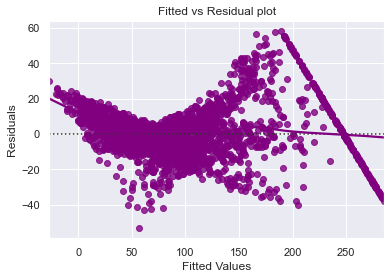

```python
# let's plot the fitted values vs residuals

sns.residplot(
    data=df_pred, x="Fitted Values", y="Residuals", color="purple", lowess=True
)
plt.xlabel("Fitted Values")
plt.ylabel("Residuals")
plt.title("Fitted vs Residual plot")
plt.show()
```

### TEST FOR NORMALITY

**Why the test?**

- Error terms, or residuals, should be normally distributed. If the error terms are not normally distributed, confidence intervals of the coefficient estimates may become too wide or narrow. Once confidence interval becomes unstable, it leads to difficulty in estimating coefficients based on minimization of least squares. Non-normality suggests that there are a few unusual data points that must be studied closely to make a better model.

**How to check normality?**

- The shape of the histogram of residuals can give an initial idea about the normality.
- It can also be checked via a Q-Q plot of residuals. If the residuals follow a normal distribution, they will make a straight line plot, otherwise not.
- Other tests to check for normality includes the Shapiro-Wilk test.
  - Null hypothesis: Residuals are normally distributed
  - Alternate hypothesis: Residuals are not normally distributed

**How to fix if this assumption is not followed?**

- We can apply transformations like log, exponential, arcsinh, etc. as per our data.

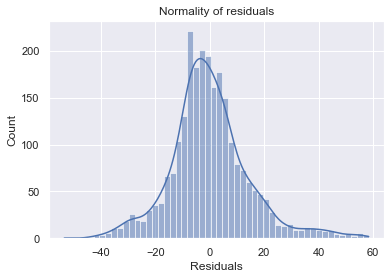

```python
sns.histplot(data=df_pred, x="Residuals", kde=True)
plt.title("Normality of residuals")
plt.show()
```

- The histogram of residuals does have a bell shape.
- Let's check the Q-Q plot.

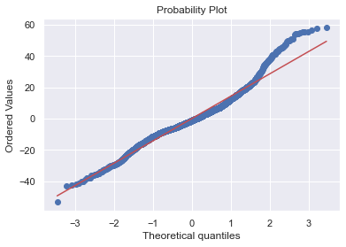

```python
import pylab
import scipy.stats as stats

stats.probplot(df_pred["Residuals"], dist="norm", plot=pylab)
plt.show()
```

- The residuals more or less follow a straight line except for the tails.
- Let's check the results of the Shapiro-Wilk test.

```python
stats.shapiro(df_pred["Residuals"])
```

```
ShapiroResult(statistic=0.964061975479126, pvalue=1.823933976431459e-24)
```

### TEST FOR HOMOSCEDASTICITY

- **Homoscedascity**: If the variance of the residuals is symmetrically distributed across the regression line, then the data is said to be homoscedastic.
- **Heteroscedascity**: If the variance is unequal for the residuals across the regression line, then the data is said to be heteroscedastic.

**Why the test?**

- The presence of non-constant variance in the error terms results in heteroscedasticity. Generally, non-constant variance arises in presence of outliers.

**How to check for homoscedasticity?**

- The residual vs fitted values plot can be looked at to check for homoscedasticity. In the case of heteroscedasticity, the residuals can form an arrow shape or any other non-symmetrical shape.
- The goldfeldquandt test can also be used. If we get a p-value > 0.05 we can say that the residuals are homoscedastic. Otherwise, they are heteroscedastic.
  - Null hypothesis: Residuals are homoscedastic
  - Alternate hypothesis: Residuals have heteroscedasticity

**How to fix if this assumption is not followed?**

- Heteroscedasticity can be fixed by adding other important features or making transformations.

```python
import statsmodels.stats.api as sms
from statsmodels.compat import lzip

name = ["F statistic", "p-value"]
test = sms.het_goldfeldquandt(df_pred["Residuals"], x_train2)
lzip(name, test)
```

```
[('F statistic', 1.0656243307745283), ('p-value', 0.1315652664055853)]
```

**Since p-value > 0.05, we can say that the residuals are homoscedastic. So, this assumption is satisfied.**

```python
# predictions on the test set
pred = olsmod2.predict(x_test2)

df_pred_test = pd.DataFrame({"Actual": y_test, "Predicted": pred})
df_pred_test.sample(10, random_state=1)
```

|  | Actual | Predicted |
| --- | --- | --- |
| 2098 | 30.52 | 23.08 |
| 278 | 195.67 | 185.38 |
| 26 | 247.19 | 222.79 |
| 2910 | 89.97 | 88.09 |
| 2631 | 69.20 | 65.45 |
| 1582 | 89.58 | 109.41 |
| 2110 | 247.19 | 267.11 |
| 3160 | 65.34 | 66.30 |
| 2817 | 115.77 | 108.88 |
| 549 | 39.29 | 48.60 |

- We can observe here that our model has returned pretty good prediction results, and the actual and predicted values are comparable.
- We can also visualize comparison result as a bar graph.

**Note**: As the number of records is large, for representation purpose, we are taking a sample of 25 records only.

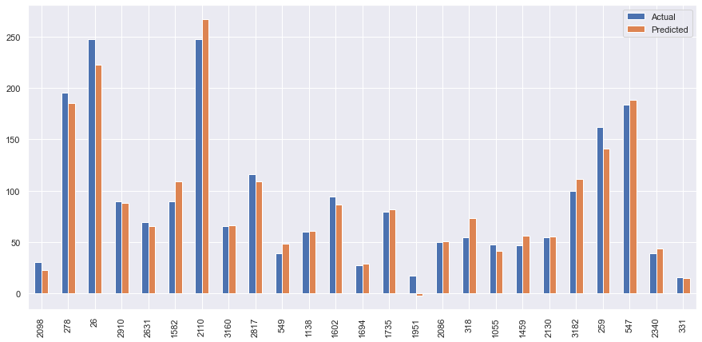

```python
df1 = df_pred_test.sample(25, random_state=1)
df1.plot(kind="bar", figsize=(15, 7))
plt.show()
```

```python
# checking model performance on train set (seen 70% data)
print("Training Performance\n")
olsmod2_train_perf = model_performance_regression(olsmod2, x_train2, y_train)
olsmod2_train_perf
```

```
Training Performance
```

|  | RMSE | MAE | R-squared | Adj. R-squared | MAPE |
| --- | --- | --- | --- | --- | --- |
| 0 | 14.54 | 10.60 | 0.95 | 0.95 | 19.71 |

```python
# checking model performance on test set (seen 30% data)
print("Test Performance\n")
olsmod2_test_perf = model_performance_regression(olsmod2, x_test2, y_test)
olsmod2_test_perf
```

```
Test Performance
```

|  | RMSE | MAE | R-squared | Adj. R-squared | MAPE |
| --- | --- | --- | --- | --- | --- |
| 0 | 14.42 | 10.52 | 0.95 | 0.95 | 16.90 |

- The model is able to explain ~95% of the variation in the data, which is very good.
- The train and test RMSE and MAE are low and comparable. So, our model is not suffering from overfitting.
- The MAPE on the test set suggests we can predict within 16.90 % of the used price.
- Hence, we can conclude the model *olsmod2* is good for prediction as well as inference purposes.

**Let's compare the initial model created with sklearn and the final statsmodels model.**

```python
# training performance comparison

models_train_comp_df = pd.concat(
    [linearregression_train_perf.T, olsmod2_train_perf.T], axis=1,
)

models_train_comp_df.columns = [
    "Linear Regression sklearn",
    "Linear Regression statsmodels",
]

print("Training performance comparison:")
models_train_comp_df
```

```
Training performance comparison:
```

|  | Linear Regression sklearn | Linear Regression statsmodels |
| --- | --- | --- |
| RMSE | 14.52 | 14.54 |
| MAE | 10.59 | 10.60 |
| R-squared | 0.95 | 0.95 |
| Adj. R-squared | 0.95 | 0.95 |
| MAPE | 19.68 | 19.71 |

```python
# test performance comparison

models_test_comp_df = pd.concat(
    [linearregression_test_perf.T, olsmod2_test_perf.T], axis=1,
)

models_test_comp_df.columns = [
    "Linear Regression sklearn",
    "Linear Regression statsmodels",
]

print("Test performance comparison:")
models_test_comp_df
```

```
Test performance comparison:
```

|  | Linear Regression sklearn | Linear Regression statsmodels |
| --- | --- | --- |
| RMSE | 14.41 | 14.42 |
| MAE | 10.51 | 10.52 |
| R-squared | 0.95 | 0.95 |
| Adj. R-squared | 0.95 | 0.95 |
| MAPE | 16.88 | 16.90 |

- The performance of the two models is very close to each other.

**Let's recreate the final statsmodels model and print it's summary to gain insights.**

## Final Model Summary

```python
olsmodel_final = sm.OLS(y_train, x_train2).fit()
print(olsmodel_final.summary())
```

```
                            OLS Regression Results
==============================================================================
Dep. Variable:             used_price   R-squared:                       0.951
Model:                            OLS   Adj. R-squared:                  0.951
Method:                 Least Squares   F-statistic:                     6086.
Date:                Sat, 23 Oct 2021   Prob (F-statistic):               0.00
Time:                        02:05:06   Log-Likelihood:                -10235.
No. Observations:                2499   AIC:                         2.049e+04
Df Residuals:                    2490   BIC:                         2.054e+04
Df Model:                           8
Covariance Type:            nonrobust
=====================================================================================
                        coef    std err          t      P>|t|      [0.025      0.975]
-------------------------------------------------------------------------------------
const                60.9782      1.805     33.776      0.000      57.438      64.518
new_price             0.3996      0.003    153.283      0.000       0.394       0.405
days_used            -0.0819      0.002    -40.081      0.000      -0.086      -0.078
os_Others            -3.4657      1.280     -2.707      0.007      -5.976      -0.955
4g_yes               -2.6559      0.744     -3.572      0.000      -4.114      -1.198
5g_yes                7.2467      1.873      3.868      0.000       3.573      10.920
release_year_2018     6.5914      1.156      5.700      0.000       4.324       8.859
release_year_2019    13.2360      1.299     10.190      0.000      10.689      15.783
release_year_2020     7.4472      1.739      4.283      0.000       4.038      10.856
==============================================================================
Omnibus:                      232.477   Durbin-Watson:                   1.961
Prob(Omnibus):                  0.000   Jarque-Bera (JB):              473.173
Skew:                           0.599   Prob(JB):                    1.79e-103
Kurtosis:                       4.763   Cond. No.                     6.62e+03
==============================================================================

Notes:
[1] Standard Errors assume that the covariance matrix of the errors is correctly specified.
[2] The condition number is large, 6.62e+03. This might indicate that there are
strong multicollinearity or other numerical problems.
```

## Conclusions

- From the final coefficients of Statsmodel (oldsmodel_final), we can see the following
  - Both the final Statsmodel model and Sklearmodel have an Adjusted R^2 of 0.951. This means that the model has the ability to explain `95.1%` of the variation between actual and predicted used prices.
  - On the Test Data, The SKLearn model has a `RMSE` of `14.41` vs `14.42` of the Statsmodel.
  - For every 1 Eurodollar of the new price of a phone, the used price will be `39.9%` or ~ `0.40` Euros
  - Being 5G adds 7.24 Euros to the unit price
  - Having only 4G capability detracts 2.65 euros from the price.
  - A cell phone model released in 2019 contibutes 13.23 euro dollars to price as compared to a 2020 model that adds 7.44 euro dollars
  - The target variable `used_price` is highly sensitive to the predictors `new_price`, `days_used`, `os_Others`, `4g_yes`, `5g_yes`and `release_years` `2018-2020`

## Answer to key questions

Questions:

**What does the distribution of used phone prices look like?**

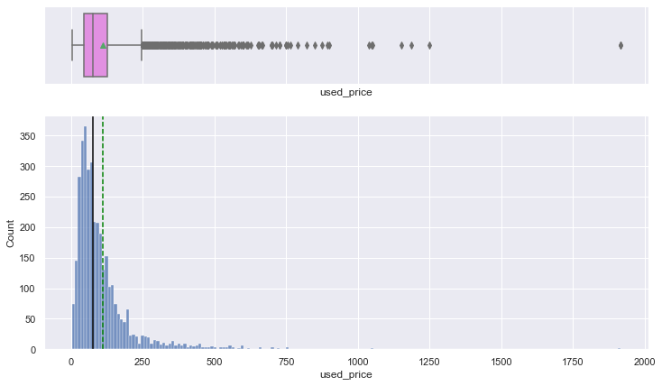

- Used price appears to be right skewed.
- There are a lot of outliers above the upper whisker.
- Most of the prices are less than 250 euros

**What percentage of the used phone market is dominated by Android devices?**

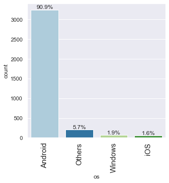

- From the plot above, ~91% of the market is dominated by Android phones

**The amount of RAM is important for the smooth functioning of a phone. How does the amount of RAM vary with the brand?**

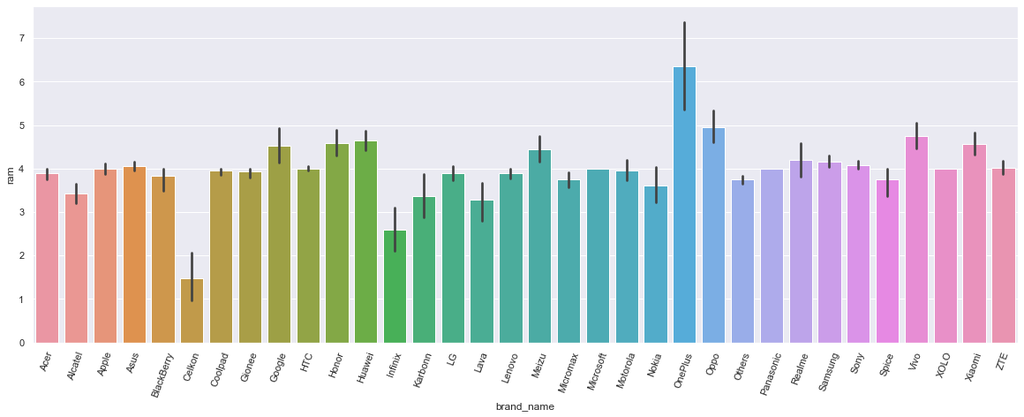

- One plus models have the highest mean ram of all the brands at 6.36 GB
- Oppo models have the second highest mean ram of all brands at 4.96 GB

**A large battery often increases a phone's weight, making it feel uncomfortable in the hands. How does the weight vary for phones offering large batteries (more than 4500 mAh)?**

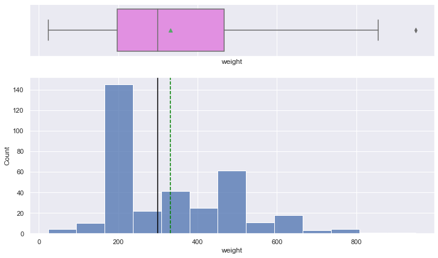

For phones with battery capacities > 4500mah these are the observations below.

- There are over 140 phones with weights in the 200 g class.
- The mean weight of phones over 4500mAh is 330 grams
- The data set has outliers

**Bigger screens are desirable for entertainment purposes as they offer a better viewing experience. How many phones are available across different brands with a screen size larger than 6 inches?**

3450 phones are available with a screen size > 6 inches. With OnePlus Phones having the largest avg screen size. [Output 28]

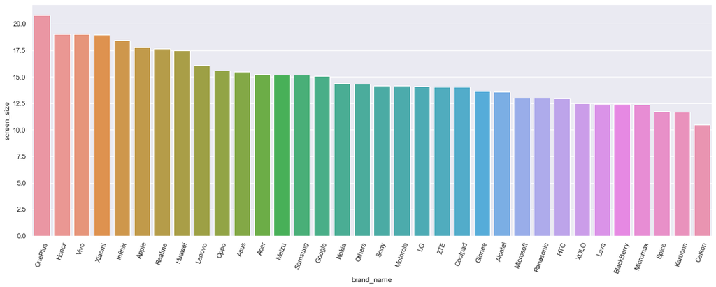

**Budget phones nowadays offer great selfie cameras, allowing us to capture our favorite moments with loved ones. What is the distribution of budget phones offering greater than 8MP selfie cameras across brands?**

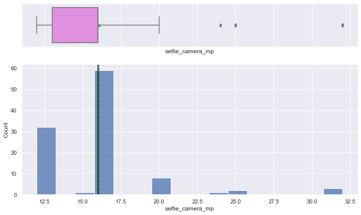

-There are 106 budget phones that have cameras with selfie camera resolution greater than 8 mp [Output 17]

- The distribution is right skewed with a mean of around 16mp

Which attributes are highly correlated with the used phone price?

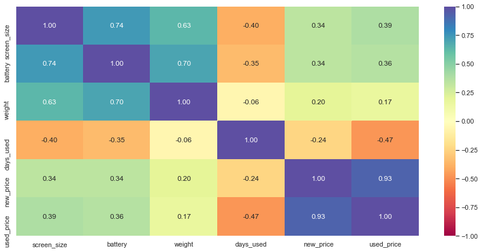

## Actionable Insights

- The ReCell company now has a model that can predict the used prices of cell phones based on the following predictors :
  - 4 or 5 g capability, release year from 2018 to 2020 upwards, new price, days used and the operating system if it falls under the `Others` category.
  - The model is able to predict the used prices withing 16.9% of the actual price (based on the MAPE).
  - The company should focus on 2018 model upwards to have a positive impact on their revenue.
  - The used phone market is dominated with Android Phones that make up 91% of it.
  - The used prices is a skewed distibution with most of the prices less than 250 euros, and a mean used price of 110 euros
  - There are 106 budget phones that have a selfie camera more than 8mp.